# Empirical Comparison of Classification Algorithms

**An empirical study in the style of Caruana & Niculescu-Mizil (2006)**

This notebook systematically compares multiple classification algorithms across diverse datasets with varying training set sizes to understand their relative performance and generalization behavior.

## 1. Experimental Setup

```python
# Import necessary libraries
import pandas as pd
import numpy as np
import matplotlib.pyplot as plt
import seaborn as sns
import time
import json
import warnings
from pathlib import Path
from ucimlrepo import fetch_ucirepo
from collections import OrderedDict
from matplotlib.container import BarContainer


from sklearn.model_selection import train_test_split, cross_val_score, GridSearchCV, StratifiedKFold, RandomizedSearchCV
from sklearn.preprocessing import StandardScaler, LabelEncoder, OneHotEncoder, FunctionTransformer
from sklearn.ensemble import RandomForestClassifier
from sklearn.svm import SVC
from sklearn.neighbors import KNeighborsClassifier
from sklearn.linear_model import LogisticRegression
from sklearn.naive_bayes import GaussianNB
from sklearn.tree import DecisionTreeClassifier
from sklearn.metrics import accuracy_score, precision_score, recall_score, f1_score, roc_auc_score
from sklearn.metrics import confusion_matrix, roc_curve, ConfusionMatrixDisplay
from sklearn.compose import ColumnTransformer
from sklearn.pipeline import Pipeline
from sklearn.impute import SimpleImputerx
from joblib import Memory


# Set random seed for reproducibility
RANDOM_STATE = 42
np.random.seed(RANDOM_STATE)

# Configure display settings
pd.set_option('display.max_columns', None)
plt.style.use('seaborn-v0_8-darkgrid')
warnings.filterwarnings('ignore')
```

## 2. Dataset Loading & Description

Load four UCI datasets with different characteristics:

- **Bank Marketing** (id=222): Target `y` - Predicting term deposit subscription
- **Online Shoppers Purchasing Intention** (id=468): Target `Revenue` - E-commerce purchase prediction
- **Iranian Churn** (id=563): Target `Churn` - Customer churn prediction
- **Online News Popularity** (id=332): Target `shares` - Predicting high vs. low article popularity (binarized at median)

Display basic statistics for each dataset (size, features, class distribution).

```python
# Load datasets
bank_marketing = fetch_ucirepo(id=222)
X_bank = bank_marketing.data.features
y_bank = bank_marketing.data.targets
print(f"Bank Marketing Dataset - Features shape: {X_bank.shape}")
print(f"Bank Marketing Dataset - Target shape: {y_bank.shape}")
print(f"Bank Marketing Dataset - Target column(s): {list(y_bank.columns)}")
print()

online_shoppers = fetch_ucirepo(id=468)
X_shoppers = online_shoppers.data.features
y_shoppers = online_shoppers.data.targets
print(f"Online Shoppers Dataset - Features shape: {X_shoppers.shape}")
print(f"Online Shoppers Dataset - Target shape: {y_shoppers.shape}")
print(f"Online Shoppers Dataset - Target column(s): {list(y_shoppers.columns)}")
print()

iranian_churn = fetch_ucirepo(id=563)
X_churn = iranian_churn.data.features
y_churn = iranian_churn.data.targets
print(f"Iranian Churn Dataset - Features shape: {X_churn.shape}")
print(f"Iranian Churn Dataset - Target shape: {y_churn.shape}")
print(f"Iranian Churn Dataset - Target column(s): {list(y_churn.columns)}")
print()

news_popularity = fetch_ucirepo(id=332)
X_news = news_popularity.data.features
y_news_raw = news_popularity.data.targets
print(f"Online News Popularity Dataset - Features shape: {X_news.shape}")
print(f"Online News Popularity Dataset - Target shape: {y_news_raw.shape}")
print(f"Online News Popularity Dataset - Target column(s): {list(y_news_raw.columns)}")

# Binarize the target variable at median for binary classification
shares = y_news_raw.iloc[:, 0].values if isinstance(y_news_raw, pd.DataFrame) else y_news_raw.values
median_shares = np.median(shares)
y_news_binary = (shares > median_shares).astype(int)
y_news = pd.DataFrame({'popular': y_news_binary})
print(f"Binarized target at median ({median_shares:.0f} shares):")
print(f"  Class 0 (≤ median): {(y_news_binary == 0).sum()} samples")
print(f"  Class 1 (> median): {(y_news_binary == 1).sum()} samples")
print()

# Store datasets in a dictionary
datasets = {
    'Bank Marketing': (X_bank, y_bank),
    'Online Shoppers': (X_shoppers, y_shoppers),
    'Iranian Churn': (X_churn, y_churn),
    'Online News Popularity': (X_news, y_news)
}
```

[output not shown]

### 2.2 Dataset Summary Statistics

```python
# Display summary statistics for each dataset

for dataset_name, (X, y) in datasets.items():
    print(f"\n{'-' * 80}")
    print(f"Dataset: {dataset_name}")

    # Number of samples
    n_samples = X.shape[0]
    print(f"\n Number of samples: {n_samples:,}")

    # Number of features
    n_features = X.shape[1]
    print(f" Number of features: {n_features}")

    # Feature types breakdown
    numeric_features = X.select_dtypes(include=[np.number]).columns.tolist()
    categorical_features = X.select_dtypes(include=['object', 'bool']).columns.tolist()

    print(f"   - Numeric features: {len(numeric_features)}")
    print(f"   - Categorical features: {len(categorical_features)}")

    # Missing values
    missing_counts = X.isnull().sum()
    total_missing = missing_counts.sum()

    if total_missing > 0:
        print(f"\n Missing values: {total_missing:,} total")
        print("   Features with missing values:")
        for col, count in missing_counts[missing_counts > 0].items():
            pct = (count / n_samples) * 100
            print(f"     - {col}: {count:,} ({pct:.2f}%)")
    else:
        print(f"\nMissing values: None")

    # Class distribution
    target_col = y.columns[0]
    class_counts = y[target_col].value_counts().sort_index()

    print(f"\nTarget variable: '{target_col}'")
    print(f"   Class distribution:")
    for class_label, count in class_counts.items():
        pct = (count / n_samples) * 100
        print(f"     - {class_label}: {count:,} ({pct:.2f}%)")

    # Class balance check
    max_class_pct = (class_counts.max() / n_samples) * 100
    if max_class_pct > 70:
        print(f"    Imbalanced dataset (majority class: {max_class_pct:.1f}%)")
    else:
        print(f"   Relatively balanced dataset")
```

```
================================================================================
DATASET SUMMARY STATISTICS
================================================================================

================================================================================
Dataset: Bank Marketing
================================================================================

 Number of samples: 45,211
 Number of features: 16
   - Numeric features: 7
   - Categorical features: 9

 Missing values: 52,124 total
   Features with missing values:
     - job: 288 (0.64%)
     - education: 1,857 (4.11%)
     - contact: 13,020 (28.80%)
     - poutcome: 36,959 (81.75%)

Target variable: 'y'
   Class distribution:
     - no: 39,922 (88.30%)
     - yes: 5,289 (11.70%)
    Imbalanced dataset (majority class: 88.3%)

================================================================================
Dataset: Online Shoppers
================================================================================

 Number of samples: 12,330
 Number of features: 17
   - Numeric features: 14
   - Categorical features: 3

Missing values: None

Target variable: 'Revenue'
   Class distribution:
     - False: 10,422 (84.53%)
```

[output cut: 25 more lines]

```
 Number of features: 58
   - Numeric features: 58
   - Categorical features: 0

Missing values: None

Target variable: 'popular'
   Class distribution:
     - 0: 20,082 (50.66%)
     - 1: 19,562 (49.34%)
   Relatively balanced dataset

================================================================================
Summary complete!
================================================================================
```

## 2.3 Exploratory Data Analysis

```python
# Dataset Summary Table

summary_data = []

for dataset_name, (X, y) in datasets.items():
    n_samples = X.shape[0]
    n_features = X.shape[1]

    # Get number of classes
    target_col = y.columns[0]
    n_classes = y[target_col].nunique()

    # Get class distribution info
    class_counts = y[target_col].value_counts()
    majority_class_pct = (class_counts.max() / n_samples) * 100

    summary_data.append({
        'Dataset': dataset_name,
        'Samples': f'{n_samples:,}',
        'Features': n_features,
        'Classes': n_classes,
        'Majority Class %': f'{majority_class_pct:.1f}%',
        'Samples/Features Ratio': f'{n_samples/n_features:.1f}'
    })

summary_df = pd.DataFrame(summary_data)

print("\nDataset Summary Table:")
summary_df
```

```
Dataset Summary Table:
```

|  | Dataset | Samples | Features | Classes | Majority Class % | Samples/Features Ratio |
| --- | --- | --- | --- | --- | --- | --- |
| 0 | Bank Marketing | 45,211 | 16 | 2 | 88.3% | 2825.7 |
| 1 | Online Shoppers | 12,330 | 17 | 2 | 84.5% | 725.3 |
| 2 | Iranian Churn | 3,150 | 13 | 2 | 84.3% | 242.3 |
| 3 | Online News Popularity | 39,644 | 58 | 2 | 50.7% | 683.5 |

**Key Observations:**

- Dataset size affects:
  - Generalization capability (larger => better generalization)
  - Training time complexity (larger => slower training)
  - Variance in performance estimates (smaller => higher variance)
- Samples/Features ratio indicates potential for overfitting
  - Low ratio => higher risk of overfitting, especially for complex models
- Class imbalance requires stratified sampling and careful metric interpretation

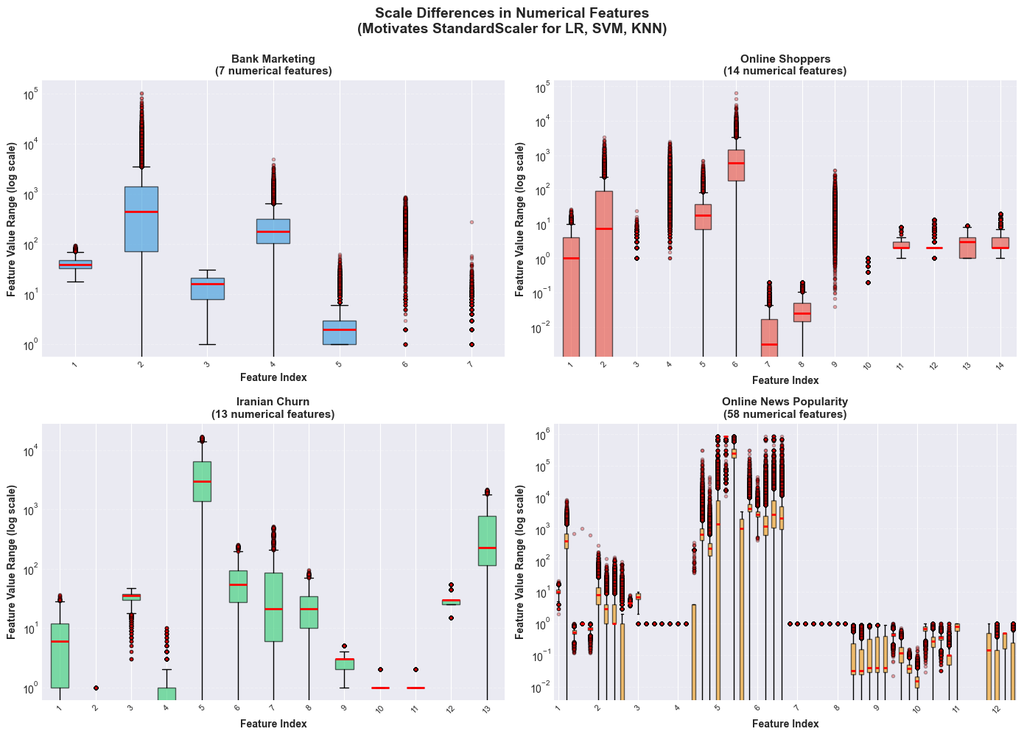

```
✓ Feature scale analysis complete
  → Large scale differences require StandardScaler
  → Critical for distance-based (KNN, SVM) and gradient-based (LR) algorithms
```

```python
# Figure 3: Scale Differences in Numerical Features

dataset_colors = ['#3498db', '#e74c3c', '#2ecc71', '#f39c12']

fig3, axes3 = plt.subplots(2, 2, figsize=(14, 10))
axes3 = axes3.flatten()

for idx, (dataset_name, (X, y)) in enumerate(datasets.items()):
    ax = axes3[idx]

    # Select only numerical columns
    numeric_cols = X.select_dtypes(include=[np.number]).columns.tolist()

    if len(numeric_cols) > 0:
        # Prepare data for boxplot (handle NaN values)
        numeric_data = X[numeric_cols].values

        # Create boxplot
        bp = ax.boxplot(numeric_data,
                        patch_artist=True,
                        boxprops=dict(facecolor=dataset_colors[idx], alpha=0.6),
                        medianprops=dict(color='red', linewidth=2),
                        whiskerprops=dict(color='black', linewidth=1),
                        capprops=dict(color='black', linewidth=1),
                        flierprops=dict(marker='o', markerfacecolor='red',
                                       markersize=3, alpha=0.3))

        # Formatting
        ax.set_xlabel('Feature Index', fontsize=10, fontweight='bold')
        ax.set_ylabel('Feature Value Range', fontsize=10, fontweight='bold')
        ax.set_title(f'{dataset_name}\n({len(numeric_cols)} numerical features)',
                     fontsize=11, fontweight='bold')
        ax.set_xticks(range(1, len(numeric_cols) + 1, max(1, len(numeric_cols)//10)))
        ax.tick_params(axis='x', rotation=45, labelsize=8)
        ax.grid(axis='y', alpha=0.3, linestyle='--')

        # Use log scale if ranges are very different
        y_range = np.nanmax(numeric_data) - np.nanmin(numeric_data)
        if y_range > 1000:
            ax.set_yscale('log')
            ax.set_ylabel('Feature Value Range (log scale)', fontsize=10, fontweight='bold')
    else:
        ax.text(0.5, 0.5, 'No numerical features',
                ha='center', va='center', fontsize=12, transform=ax.transAxes)
        ax.set_title(dataset_name, fontsize=11, fontweight='bold')

fig3.suptitle('Scale Differences in Numerical Features\n(Motivates StandardScaler for LR, SVM, KNN)',
              fontsize=14, fontweight='bold', y=0.995)
fig3.tight_layout()

# Save figure
figures_dir = Path('../figures')
figures_dir.mkdir(exist_ok=True)
fig3.savefig(figures_dir / 'fig3_feature_scales.png', dpi=300, bbox_inches='tight')

plt.show()
```

**Figure Interpretation:**

This boxplot visualization reveals the scale differences across numerical features within each dataset:

- **Extreme range variations**: Features span vastly different magnitudes (some in single digits, others in thousands or millions)
- **Log-scale necessity**: Datasets with y-range > 1000 automatically use log scale to visualize the extreme disparities
- **Outlier presence**: Red dots indicate outliers that further increase scale differences

**Why StandardScaler is Critical:**

- **Distance-based algorithms (KNN, SVM)**: Features with larger magnitudes dominate Euclidean distance calculations, causing the model to ignore smaller-scaled features
- **Gradient-based optimization (Logistic Regression)**: Unequal scales create elongated loss surface contours, leading to slow/unstable convergence and requiring careful learning rate tuning
- **Solution**: StandardScaler transforms all features to mean=0 and std=1, ensuring equal contribution to model training

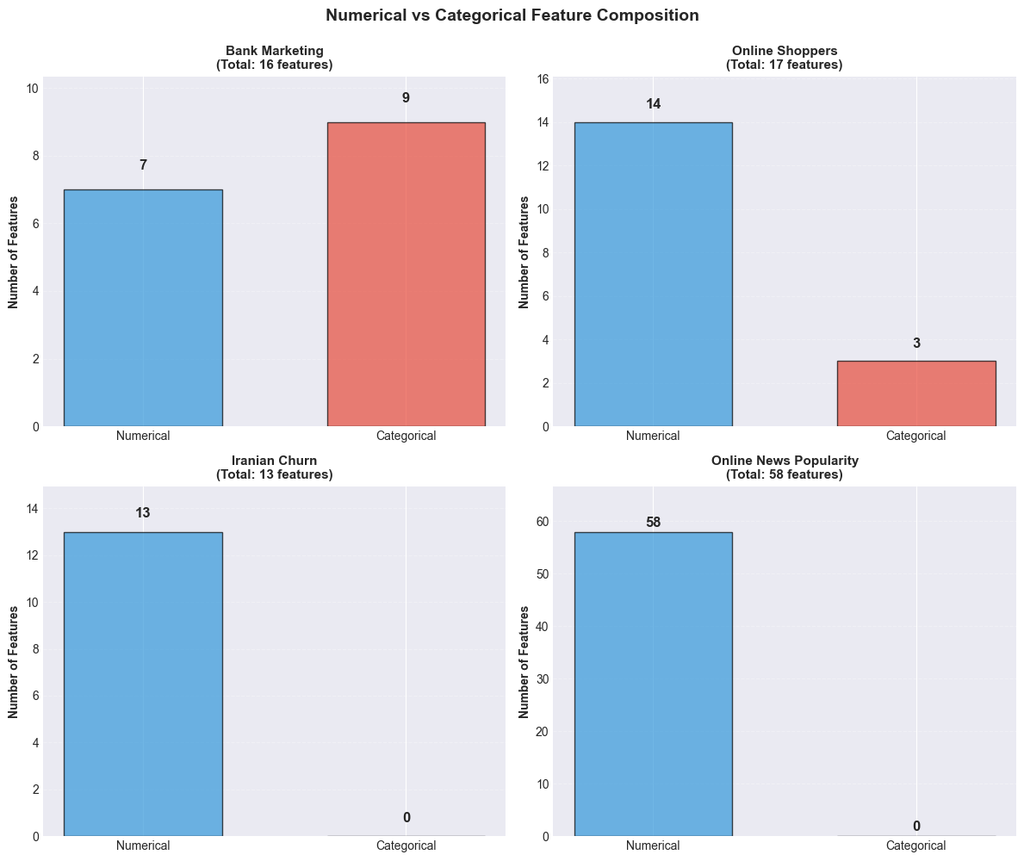

```
✓ Feature composition analysis complete
  → Mixed feature types require separate preprocessing pipelines
  → OneHotEncoder for categorical → StandardScaler for numerical
```

```python
# Figure 2: Numerical vs Categorical Feature Composition
fig2, axes2 = plt.subplots(2, 2, figsize=(12, 10))
axes2 = axes2.flatten()

for idx, (dataset_name, (X, y)) in enumerate(datasets.items()):
    ax = axes2[idx]

    # Count feature types
    n_numeric = len(X.select_dtypes(include=[np.number]).columns)
    n_categorical = len(X.select_dtypes(include=['object', 'bool']).columns)

    # Create grouped bar chart
    categories = ['Numerical', 'Categorical']
    counts = [n_numeric, n_categorical]
    bars = ax.bar(categories, counts, color=['#3498db', '#e74c3c'],
                   alpha=0.7, edgecolor='black', width=0.6)

    # Add count labels
    for bar, count in zip(bars, counts):
        ax.text(bar.get_x() + bar.get_width()/2, bar.get_height() + 0.5,
                f'{count}', ha='center', va='bottom',
                fontsize=12, fontweight='bold')

    # Formatting
    ax.set_ylabel('Number of Features', fontsize=10, fontweight='bold')
    ax.set_title(f'{dataset_name}\n(Total: {n_numeric + n_categorical} features)',
                 fontsize=11, fontweight='bold')
    ax.set_ylim(0, max(counts) * 1.15)
    ax.grid(axis='y', alpha=0.3, linestyle='--')

fig2.suptitle('Numerical vs Categorical Feature Composition',
              fontsize=14, fontweight='bold', y=0.995)
fig2.tight_layout()

# Save figure
figures_dir = Path('../figures')
figures_dir.mkdir(exist_ok=True)
fig2.savefig(figures_dir / 'fig2_feature_composition.png', dpi=300, bbox_inches='tight')

plt.show()
```

# This analysis informs our preprocessing strategy:

# - Categorical features require OneHotEncoder to convert to numerical representation

# - Numerical features require StandardScaler to normalize different scales

# - Mixed feature types necessitate ColumnTransformer for separate pipelines

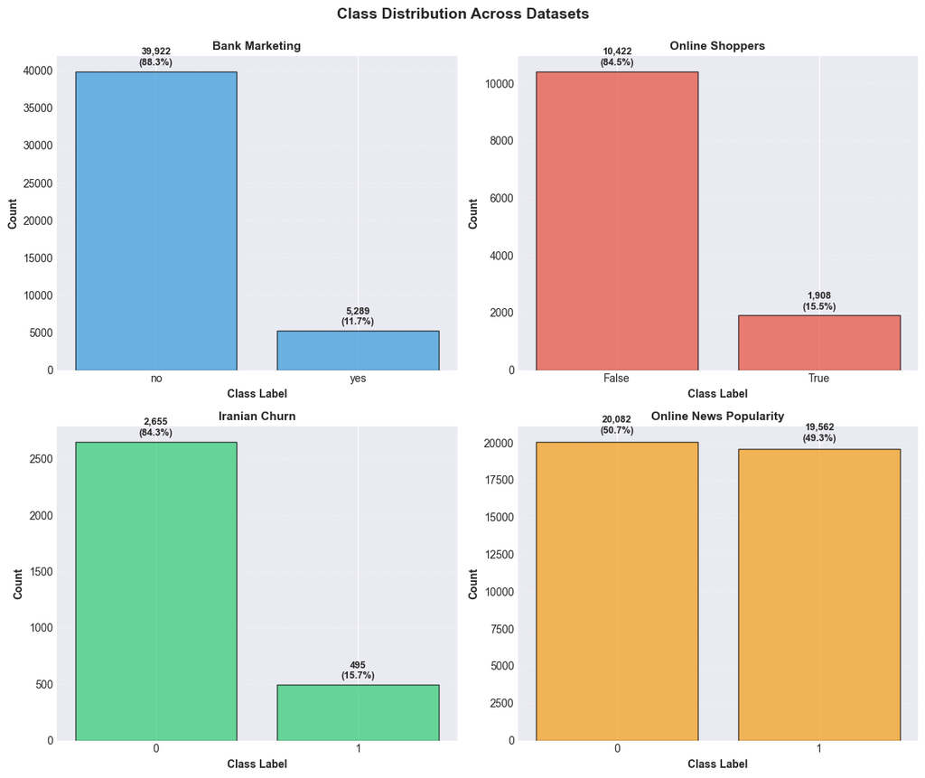

```
✓ Class distribution analysis complete
  → Imbalanced datasets require stratified sampling to maintain class proportions
```

```python
# Figure 1: Class Distribution Across Datasets
# This visualization reveals class imbalance, which necessitates stratified train/test splits
# to ensure both training and test sets maintain representative class proportions

fig1, axes1 = plt.subplots(2, 2, figsize=(12, 10))
axes1 = axes1.flatten()

dataset_colors = ['#3498db', '#e74c3c', '#2ecc71', '#f39c12']  # Consistent color scheme

for idx, (dataset_name, (X, y)) in enumerate(datasets.items()):
    ax = axes1[idx]

    # Get class distribution
    target_col = y.columns[0]
    class_counts = y[target_col].value_counts().sort_index()
    total = class_counts.sum()

    # Create bar chart
    bars = ax.bar(range(len(class_counts)), class_counts.values,
                   color=dataset_colors[idx], alpha=0.7, edgecolor='black')

    # Add count and percentage labels on bars
    for i, (count, bar) in enumerate(zip(class_counts.values, bars)):
        percentage = (count / total) * 100
        ax.text(bar.get_x() + bar.get_width()/2, bar.get_height() + total*0.01,
                f'{count:,}\n({percentage:.1f}%)',
                ha='center', va='bottom', fontsize=9, fontweight='bold')

    # Formatting
    ax.set_xlabel('Class Label', fontsize=10, fontweight='bold')
    ax.set_ylabel('Count', fontsize=10, fontweight='bold')
    ax.set_title(dataset_name, fontsize=11, fontweight='bold')
    ax.set_xticks(range(len(class_counts)))
    ax.set_xticklabels(class_counts.index)
    ax.grid(axis='y', alpha=0.3, linestyle='--')

fig1.suptitle('Class Distribution Across Datasets', fontsize=14, fontweight='bold', y=0.995)
fig1.tight_layout()

# Save figure
figures_dir = Path('../figures')
figures_dir.mkdir(exist_ok=True)
fig1.savefig(figures_dir / 'fig1_class_distribution.png', dpi=300, bbox_inches='tight')

plt.show()
```

# This visualization reveals class imbalance, which necessitates stratified train/test splits

# to ensure both training and test sets maintain representative class proportions

## 3. Preprocessing Pipeline

Build a unified preprocessing pipeline using scikit-learn's `ColumnTransformer`:

- **OneHotEncoder** for categorical features (handle unknown categories)
- **StandardScaler** for numeric features (zero mean, unit variance)
- Handle missing values appropriately
- Ensure pipeline is fit only on training data to prevent data leakage

```python
def make_preprocessor(X: pd.DataFrame):

    # Identify numeric and categorical columns based on pandas dtypes
    numeric_features = X.select_dtypes(include=[np.number]).columns.tolist()
    categorical_features = X.select_dtypes(include=['object', 'bool', 'category']).columns.tolist()

    # numeric pipeline: impute with median, then scale to zero mean and unit variance
    numeric_transformer = Pipeline(steps=[
        ('imputer', SimpleImputer(strategy='median')),
        ('scaler', StandardScaler())
    ])

    # categorical pipeline: impute with most frequent value, then one-hot encode, allows models to use categorical features without assuming ordinal relationships
    # handle_unknown='ignore' prevents errors if test data has unseen categories
    categorical_transformer = Pipeline(steps=[
        ('imputer', SimpleImputer(strategy='most_frequent')),
        ('onehot', OneHotEncoder(handle_unknown='ignore', sparse_output=False))
    ])

    # Combine both transformers into a single ColumnTransformer
    preprocessor = ColumnTransformer(
        transformers=[
            ('num', numeric_transformer, numeric_features),
            ('cat', categorical_transformer, categorical_features)
        ])

    return preprocessor

# Test the preprocessor on all datasets to verify
for dataset_name, (X, y) in datasets.items():
    print(f"\n{'-' * 80}")
    print(f"Dataset: {dataset_name}")
    print(f"{'-' * 80}")

    # Display original dataset information
    n_numeric = len(X.select_dtypes(include=[np.number]).columns)
    n_categorical = len(X.select_dtypes(include=['object', 'bool']).columns)

    print(f"Original shape: {X.shape}")
    print(f"  - Numeric features: {n_numeric}")
    print(f"  - Categorical features: {n_categorical}")

    # Create and fit the preprocessor
    preprocessor = make_preprocessor(X)
    X_transformed = preprocessor.fit_transform(X)

    # Display transformed dataset information
    print(f"\nTransformed shape: {X_transformed.shape}")
    print(f"  - Original features: {X.shape[1]}")
    print(f"  - After preprocessing: {X_transformed.shape[1]}")
    print(f"  - Feature expansion: +{X_transformed.shape[1] - X.shape[1]} features")
    print(f"  - Expansion factor: {X_transformed.shape[1] / X.shape[1]:.2f}x")

    # Verify no missing values after preprocessing
    n_missing = np.isnan(X_transformed).sum()
    print(f"\nMissing values after preprocessing: {n_missing}")
```

```
Preprocessing pipeline function created!

================================================================================
Testing preprocessor on all datasets...
================================================================================

--------------------------------------------------------------------------------
Dataset: Bank Marketing
--------------------------------------------------------------------------------
Original shape: (45211, 16)
  - Numeric features: 7
  - Categorical features: 9

Transformed shape: (45211, 47)
  - Original features: 16
  - After preprocessing: 47
  - Feature expansion: +31 features
  - Expansion factor: 2.94x

Missing values after preprocessing: 0
✓ Preprocessing successful for Bank Marketing

--------------------------------------------------------------------------------
Dataset: Online Shoppers
--------------------------------------------------------------------------------
Original shape: (12330, 17)
  - Numeric features: 14
  - Categorical features: 3

Transformed shape: (12330, 29)
  - Original features: 17
  - After preprocessing: 29
  - Feature expansion: +12 features
  - Expansion factor: 1.71x

Missing values after preprocessing: 0
✓ Preprocessing successful for Online Shoppers

--------------------------------------------------------------------------------
Dataset: Iranian Churn
```

[output cut: 63 more lines]

[output not shown]

## 4. Models & Hyperparameter Grids

```python
from sklearn.naive_bayes import GaussianNB
from sklearn.preprocessing import FunctionTransformer
from sklearn.tree import DecisionTreeClassifier
from collections import OrderedDict

def to_dense(X):
    if hasattr(X, 'toarray'):
        return X.toarray()
    return X

def build_model_specs(preprocessor, memory=None):
    # Create ordered dictionary to store model specifications
    model_specs = OrderedDict()

    # 1. Logistic Regression
    model_specs['LogisticRegression'] = {
        'pipeline': Pipeline([
            ('preprocess', preprocessor),
            ('model', LogisticRegression(max_iter=500, random_state=RANDOM_STATE, n_jobs=-1))
        ], memory=memory),
        'param_grid': {
            'model__C': [0.1, 1, 10]
        },
        'search_method': 'grid'
    }

    # 2. Support Vector Machine (RBF kernel)
    model_specs['SVM_RBF'] = {
        'pipeline': Pipeline([
            ('preprocess', preprocessor),
            ('model', SVC(kernel='rbf', probability=False, random_state=RANDOM_STATE))
        ], memory=memory),
        'param_grid': {
            'model__C': [0.1, 1, 10],
            'model__gamma': ['scale']
        },
        'search_method': 'random',
        'n_iter': 6
    }

    # 3. Random Forest
    model_specs['RandomForest'] = {
        'pipeline': Pipeline([
            ('preprocess', preprocessor),
            ('model', RandomForestClassifier(random_state=RANDOM_STATE, n_jobs=-1))
        ], memory=memory),
        'param_grid': {
            'model__n_estimators': [200],
            'model__max_depth': [None, 20],
            'model__min_samples_leaf': [1, 5]
        },
        'search_method': 'random',
        'n_iter': 8
    }

    # 4. Decision Tree
    model_specs['DecisionTree'] = {
        'pipeline': Pipeline([
            ('preprocess', preprocessor),
            ('model', DecisionTreeClassifier(random_state=RANDOM_STATE))
        ], memory=memory),
        'param_grid': {
            'model__max_depth': [None, 10, 30],
            'model__min_samples_leaf': [1]
        },
        'search_method': 'grid'
    }

    # 5. Gaussian Naive Bayes
    model_specs['GaussianNB'] = {
        'pipeline': Pipeline([
            ('preprocess', preprocessor),
            ('todense', FunctionTransformer(to_dense, accept_sparse=True)),
            ('model', GaussianNB())
        ]),
        'param_grid': {
            'model__var_smoothing': [1e-9, 1e-8, 1e-7]
        },
        'search_method': 'grid'
    }

    return model_specs


# Test the function with a sample dataset
X_sample, y_sample = datasets['Bank Marketing']
sample_preprocessor = make_preprocessor(X_sample)

# Build model specifications
model_specs = build_model_specs(sample_preprocessor, memory=None)

print(f"\nDefined {len(model_specs)} model pipelines:\n")

for model_name, specs in model_specs.items():
    pipeline = specs['pipeline']
    param_grid = specs['param_grid']
    search_method = specs.get('search_method', 'grid')

    print(f"{model_name}:")
    print(f"  Pipeline steps: {[step[0] for step in pipeline.steps]}")
    print(f"  Hyperparameters to tune: {list(param_grid.keys())}")

    # Count total hyperparameter combinations
    n_combinations = 1
    for param_values in param_grid.values():
        n_combinations *= len(param_values)

    if search_method == 'random':
        n_iter = specs.get('n_iter', 10)
        print(f"  Search method: RandomizedSearchCV (n_iter={n_iter})")
        print(f"  Total combinations: {n_combinations} (sampling {n_iter})")
    else:
        print(f"  Search method: GridSearchCV")
        print(f"  Grid search combinations: {n_combinations}")
    print()
```

```
Model specification function created!

================================================================================
Building model specifications with sample preprocessor...
================================================================================

Defined 5 model pipelines:

LogisticRegression:
  Pipeline steps: ['preprocess', 'model']
  Hyperparameters to tune: ['model__C']
  Search method: GridSearchCV
  Grid search combinations: 3

SVM_RBF:
  Pipeline steps: ['preprocess', 'model']
  Hyperparameters to tune: ['model__C', 'model__gamma']
  Search method: RandomizedSearchCV (n_iter=6)
  Total combinations: 3 (sampling 6)

RandomForest:
  Pipeline steps: ['preprocess', 'model']
  Hyperparameters to tune: ['model__n_estimators', 'model__max_depth', 'model__min_samples_leaf']
  Search method: RandomizedSearchCV (n_iter=8)
  Total combinations: 4 (sampling 8)

DecisionTree:
  Pipeline steps: ['preprocess', 'model']
  Hyperparameters to tune: ['model__max_depth', 'model__min_samples_leaf']
  Search method: GridSearchCV
  Grid search combinations: 3

GaussianNB:
  Pipeline steps: ['preprocess', 'todense', 'model']
  Hyperparameters to tune: ['model__var_smoothing']
  Search method: GridSearchCV
  Grid search combinations: 3

================================================================================
Model specifications built successfully!
================================================================================
```

## 5. Experiment Runner

Execute systematic experiments with the following nested structure:

- **Datasets**: 4 datasets (Bank Marketing, Online Shoppers, Iranian Churn, Online News Popularity)
- **Training sizes**: 3 splits (20%, 50%, 80% for training)
- **Repeats**: 3 independent trials per configuration (different random splits)
- **Models**: 5 classification algorithms
- **Hyperparameter tuning**: GridSearchCV/RandomizedSearchCV with 3-fold cross-validation on training set only

For each configuration, record:

- `dataset_name`: Name of dataset
- `model_name`: Name of classifier
- `train_size`: Training set proportion
- `repeat_id`: Trial number (0, 1, 2)
- `train_acc`: Accuracy on training set (after refit with best params)
- `cv_acc`: Mean cross-validation accuracy during grid search
- `test_acc`: Accuracy on held-out test set
- `best_params`: Optimal hyperparameters found
- `n_train_samples`: Number of training samples
- `n_test_samples`: Number of test samples

**Important**: Fit preprocessing pipeline and GridSearchCV only on training data to ensure fair evaluation.

```python
# Experimental configuration
TRAIN_SIZES = [0.2, 0.5, 0.8]
N_REPEATS = 3
CV_FOLDS = 3

# Setup pipeline caching for faster CV
memory = Memory(location='.cache', verbose=0)

def run_one_setting(X, y, train_frac, seed, model_specs, cv_folds):
    # Extract target values as 1D array (handle DataFrame or Series)
    if isinstance(y, pd.DataFrame):
        y_values = y.iloc[:, 0].values
    else:
        y_values = y.values

    # train/test split to ensure class distribution is preserved
    X_train, X_test, y_train, y_test = train_test_split(
        X, y_values,
        train_size=train_frac,
        random_state=seed,
        stratify=y_values  # Maintain class proportions in both splits
    )

    n_train_samples = X_train.shape[0]
    n_test_samples = X_test.shape[0]

    results = []

    # Iterate through each model specification
    for model_name, specs in model_specs.items():

        # Extract pipeline and hyperparameter grid
        pipeline = specs['pipeline']
        param_grid = specs['param_grid']
        search_method = specs.get('search_method', 'grid')

        # Create stratified k-fold cross-validator
        cv_splitter = StratifiedKFold(
            n_splits=cv_folds,
            shuffle=True,
            random_state=seed
        )

        # Set up search method: GridSearchCV or RandomizedSearchCV

        if search_method == 'random':
            # Use RandomizedSearchCV for SVM and Random Forest
            n_iter = specs.get('n_iter', 10)
            grid_search = RandomizedSearchCV(
                estimator=pipeline,
                param_distributions=param_grid,
                n_iter=n_iter,
                scoring='accuracy',
                cv=cv_splitter,
                n_jobs=-1,
                refit=True,
                verbose=0,
                random_state=seed
            )
        else:
            # Use GridSearchCV for other models
            grid_search = GridSearchCV(
                estimator=pipeline,
                param_grid=param_grid,
                scoring='accuracy',
                cv=cv_splitter,
                n_jobs=-1,
                refit=True,
                verbose=0
            )

        # Time the training process
        start_time = time.perf_counter()

        # Fit GridSearchCV on TRAINING DATA ONLY
        # The preprocessing pipeline will be fit on each CV fold's training portion
        # This ensures no information from validation folds leaks into preprocessing
        grid_search.fit(X_train, y_train)

        end_time = time.perf_counter()
        runtime_sec = end_time - start_time

        # After GridSearchCV completes, the best model is automatically refit on ALL training data
        # Now we can evaluate performance on train and test sets

        # 1. Training accuracy: how well does the model fit the training data?
        # Note: This is computed on the SAME data used for training, so expect high accuracy
        y_train_pred = grid_search.predict(X_train)
        train_acc = accuracy_score(y_train, y_train_pred)

        # 2. Cross-validation accuracy: average performance across CV folds
        cv_acc = grid_search.best_score_

        # 3. Test accuracy: performance on completely unseen test data

        y_test_pred = grid_search.predict(X_test)
        test_acc = accuracy_score(y_test, y_test_pred)

        # Extract best hyperparameters found by GridSearchCV and convert to JSON-like string for storage
        best_params = json.dumps(grid_search.best_params_, sort_keys=True)

        # Store all results for this model
        result = {
            'model_name': model_name,
            'train_size': train_frac,
            'seed': seed,
            'train_acc': train_acc,
            'cv_acc': cv_acc,
            'test_acc': test_acc,
            'best_params': best_params,
            'n_train_samples': n_train_samples,
            'n_test_samples': n_test_samples,
            'runtime_sec': runtime_sec
        }

        results.append(result)

    return results
print(f"  Training fraction: 0.5 (50%)")
print("Experiment runner function created!")
print("\n" + "=" * 80)
print("Testing experiment runner on one setting...")
print("=" * 80)

# Test the function with one configuration
X_sample, y_sample = datasets['Bank Marketing']
sample_preprocessor = make_preprocessor(X_sample)
sample_model_specs = build_model_specs(sample_preprocessor, memory=memory)

print(f"\nRunning experiment:")
print(f"  Dataset: Bank Marketing")
print(f"  Training fraction: 0.5 (50%)")
print(f"  Random seed: 42")
print(f"  CV folds: {CV_FOLDS}")
print(f"  Models: {len(sample_model_specs)}")

test_results = run_one_setting(
    X=X_sample,
    y=y_sample,
    train_frac=0.5,
    seed=42,
    model_specs=sample_model_specs,
    cv_folds=CV_FOLDS
)

print("\n" + "=" * 80)
print("Experiment runner test completed successfully!")
print("=" * 80)

print("\nResults:")
for result in test_results:
    print(f"\n{result['model_name']}:")
    print(f"  Train accuracy: {result['train_acc']:.4f}")
    print(f"  CV accuracy:    {result['cv_acc']:.4f}")
    print(f"  Test accuracy:  {result['test_acc']:.4f}")
    print(f"  Best params:    {result['best_params']}")
    print(f"  Runtime:        {result['runtime_sec']:.2f}s")

print("\n" + "=" * 80)
```

```
  Training fraction: 0.5 (50%)
Experiment runner function created!

================================================================================
Testing experiment runner on one setting...
================================================================================

Running experiment:
  Dataset: Bank Marketing
  Training fraction: 0.5 (50%)
  Random seed: 42
  CV folds: 3
  Models: 5
```

```
================================================================================
Experiment runner test completed successfully!
================================================================================

Results:

LogisticRegression:
  Train accuracy: 0.9006
  CV accuracy:    0.8997
  Test accuracy:  0.9011
  Best params:    {"model__C": 1}
  Runtime:        4.07s

SVM_RBF:
  Train accuracy: 0.9104
  CV accuracy:    0.8995
  Test accuracy:  0.9009
  Best params:    {"model__C": 1, "model__gamma": "scale"}
  Runtime:        14.55s

RandomForest:
  Train accuracy: 0.9816
  CV accuracy:    0.9017
  Test accuracy:  0.9031
  Best params:    {"model__max_depth": 20, "model__min_samples_leaf": 1, "model__n_estimators": 200}
  Runtime:        5.39s

DecisionTree:
  Train accuracy: 0.9314
  CV accuracy:    0.8934
  Test accuracy:  0.8972
  Best params:    {"model__max_depth": 10, "model__min_samples_leaf": 1}
  Runtime:        0.91s

GaussianNB:
  Train accuracy: 0.8508
  CV accuracy:    0.8496
  Test accuracy:  0.8528
  Best params:    {"model__var_smoothing": 1e-09}
  Runtime:        0.40s

================================================================================
```

```python
def run_all_experiments():
    """
    Execute the complete experimental pipeline:
    - 4 datasets × 3 train_sizes × 3 repeats × 5 models = 180 experiments

    Returns:
    --------
    results_df : pd.DataFrame
        DataFrame with all experimental results
    """

    all_results = []
    total_configs = len(datasets) * len(TRAIN_SIZES) * N_REPEATS
    config_counter = 0

    print("=" * 80)
    print("RUNNING FULL EXPERIMENT SUITE")
    print("=" * 80)
    print(f"Datasets: {len(datasets)}")
    print(f"Training sizes: {TRAIN_SIZES}")
    print(f"Repeats per configuration: {N_REPEATS}")
    print(f"Models: 5 (LogisticRegression, SVM_RBF, RandomForest, DecisionTree, GaussianNB)")
    print(f"Total configurations: {total_configs}")
    print(f"Total model runs: {total_configs * 5}")
    print("=" * 80)
    print()

    # Loop over all datasets
    for dataset_name, (X, y) in datasets.items():

        print(f"\n{'-' * 80}")
        print(f"DATASET: {dataset_name}")

        # Build preprocessor and model specs for this dataset
        preprocessor = make_preprocessor(X)
        model_specs = build_model_specs(preprocessor, memory=memory)

        # Loop over training sizes
        for train_frac in TRAIN_SIZES:

            # Loop over repeats (different random seeds)
            for repeat in range(N_REPEATS):

                config_counter += 1

                # Generate unique seed for this configuration
                # Formula ensures different seeds for different train_frac and repeats
                seed = RANDOM_STATE + 1000 * repeat + int(train_frac * 100)

                print(f"[{config_counter}/{total_configs}] "
                      f"{dataset_name} | train_size={train_frac:.1f} | repeat={repeat} | seed={seed}")

                # Run all models for this configuration
                config_results = run_one_setting(
                    X=X,
                    y=y,
                    train_frac=train_frac,
                    seed=seed,
                    model_specs=model_specs,
                    cv_folds=CV_FOLDS
                )

                # Add dataset name and repeat info to each result
                for result in config_results:
                    result['dataset'] = dataset_name
                    result['repeat'] = repeat
                    all_results.append(result)

                # Print brief summary of this configuration
                mean_test_acc = np.mean([r['test_acc'] for r in config_results])
                print(f"  Mean test accuracy: {mean_test_acc:.4f}")



    # Convert to DataFrame with organized columns
    results_df = pd.DataFrame(all_results)

    # Reorder columns for clarity
    column_order = [
        'dataset',
        'train_size',
        'repeat',
        'model_name',
        'train_acc',
        'cv_acc',
        'test_acc',
        'best_params',
        'runtime_sec',
        'n_train_samples',
        'n_test_samples',
        'seed'
    ]
    results_df = results_df[column_order]

    # Sort for easy reading
    results_df = results_df.sort_values(['dataset', 'train_size', 'repeat', 'model_name'])
    results_df = results_df.reset_index(drop=True)

    return results_df
```

[output not shown]

```python
# Execute the full experimental pipeline
print("Starting full experiment execution...")
print(f"Estimated time: 10-30 minutes depending on system performance")
print()

# Run all experiments
results_df = run_all_experiments()

# Display summary statistics
print("\n" + "=" * 80)
print("RESULTS SUMMARY")
print("=" * 80)
print(f"Total experimental runs: {len(results_df)}")
print(f"Datasets: {results_df['dataset'].nunique()}")
print(f"Models: {results_df['model_name'].nunique()}")
print(f"Training sizes: {sorted(results_df['train_size'].unique())}")
print(f"Repeats: {results_df['repeat'].nunique()}")
print()

# Show first few rows
print("First 10 rows of results:")
print(results_df.head(10))
print()

# Save to CSV
output_path = Path.cwd() / 'results.csv'
results_df.to_csv(output_path, index=False)
print(f"✓ Results saved to: {output_path}")
print(f"  File size: {output_path.stat().st_size / 1024:.2f} KB")

# Show some quick statistics
print("\n" + "=" * 80)
print("QUICK PERFORMANCE OVERVIEW")
print("=" * 80)

# Mean test accuracy by model across all configurations
mean_by_model = results_df.groupby('model_name')['test_acc'].agg(['mean', 'std'])
mean_by_model = mean_by_model.sort_values('mean', ascending=False)
print("\nMean Test Accuracy by Model:")
print(mean_by_model.to_string())

print("\n" + "=" * 80)
print("Experiment pipeline complete! Proceed to Section 6 for detailed analysis.")
print("=" * 80)
```

```
Starting full experiment execution...
Estimated time: 10-30 minutes depending on system performance

================================================================================
RUNNING FULL EXPERIMENT SUITE
================================================================================
Datasets: 4
Training sizes: [0.2, 0.5, 0.8]
Repeats per configuration: 3
Models: 5 (LogisticRegression, SVM_RBF, RandomForest, DecisionTree, GaussianNB)
Total configurations: 36
Total model runs: 180
================================================================================


================================================================================
DATASET: Bank Marketing
================================================================================
[1/36] Bank Marketing | train_size=0.2 | repeat=0 | seed=62
```

```
  → Mean test accuracy: 0.8882
[2/36] Bank Marketing | train_size=0.2 | repeat=1 | seed=1062
```

```
  → Mean test accuracy: 0.8878
[3/36] Bank Marketing | train_size=0.2 | repeat=2 | seed=2062
```

```
  → Mean test accuracy: 0.8886
[4/36] Bank Marketing | train_size=0.5 | repeat=0 | seed=92
```

```
  → Mean test accuracy: 0.8917
[5/36] Bank Marketing | train_size=0.5 | repeat=1 | seed=1092
```

```
  → Mean test accuracy: 0.8906
[6/36] Bank Marketing | train_size=0.5 | repeat=2 | seed=2092
```

```
  → Mean test accuracy: 0.8927
[7/36] Bank Marketing | train_size=0.8 | repeat=0 | seed=122
```

```
  → Mean test accuracy: 0.8924
[8/36] Bank Marketing | train_size=0.8 | repeat=1 | seed=1122
```

```
  → Mean test accuracy: 0.8920
[9/36] Bank Marketing | train_size=0.8 | repeat=2 | seed=2122
```

```
  → Mean test accuracy: 0.8924

================================================================================
DATASET: Online Shoppers
================================================================================
[10/36] Online Shoppers | train_size=0.2 | repeat=0 | seed=62
```

```
  → Mean test accuracy: 0.8534
[11/36] Online Shoppers | train_size=0.2 | repeat=1 | seed=1062
```

```
  → Mean test accuracy: 0.7983
[12/36] Online Shoppers | train_size=0.2 | repeat=2 | seed=2062
```

```
  → Mean test accuracy: 0.7906
[13/36] Online Shoppers | train_size=0.5 | repeat=0 | seed=92
```

```
  → Mean test accuracy: 0.7946
[14/36] Online Shoppers | train_size=0.5 | repeat=1 | seed=1092
```

```
  → Mean test accuracy: 0.8494
[15/36] Online Shoppers | train_size=0.5 | repeat=2 | seed=2092
```

```
  → Mean test accuracy: 0.8504
[16/36] Online Shoppers | train_size=0.8 | repeat=0 | seed=122
```

```
  → Mean test accuracy: 0.8556
[17/36] Online Shoppers | train_size=0.8 | repeat=1 | seed=1122
```

```
  → Mean test accuracy: 0.8483
[18/36] Online Shoppers | train_size=0.8 | repeat=2 | seed=2122
```

```
  → Mean test accuracy: 0.8537

================================================================================
DATASET: Iranian Churn
================================================================================
[19/36] Iranian Churn | train_size=0.2 | repeat=0 | seed=62
```

```
  → Mean test accuracy: 0.8560
[20/36] Iranian Churn | train_size=0.2 | repeat=1 | seed=1062
```

```
  → Mean test accuracy: 0.8847
[21/36] Iranian Churn | train_size=0.2 | repeat=2 | seed=2062
```

```
  → Mean test accuracy: 0.8848
[22/36] Iranian Churn | train_size=0.5 | repeat=0 | seed=92
```

```
  → Mean test accuracy: 0.8888
[23/36] Iranian Churn | train_size=0.5 | repeat=1 | seed=1092
```

```
  → Mean test accuracy: 0.8943
[24/36] Iranian Churn | train_size=0.5 | repeat=2 | seed=2092
```

```
  → Mean test accuracy: 0.8949
[25/36] Iranian Churn | train_size=0.8 | repeat=0 | seed=122
```

```
  → Mean test accuracy: 0.8911
[26/36] Iranian Churn | train_size=0.8 | repeat=1 | seed=1122
```

```
  → Mean test accuracy: 0.8997
[27/36] Iranian Churn | train_size=0.8 | repeat=2 | seed=2122
```

```
  → Mean test accuracy: 0.8914

================================================================================
DATASET: Online News Popularity
================================================================================
[28/36] Online News Popularity | train_size=0.2 | repeat=0 | seed=62
```

```
  → Mean test accuracy: 0.6167
[29/36] Online News Popularity | train_size=0.2 | repeat=1 | seed=1062
```

```
  → Mean test accuracy: 0.6301
[30/36] Online News Popularity | train_size=0.2 | repeat=2 | seed=2062
```

```
  → Mean test accuracy: 0.6298
[31/36] Online News Popularity | train_size=0.5 | repeat=0 | seed=92
```

```
  → Mean test accuracy: 0.6355
[32/36] Online News Popularity | train_size=0.5 | repeat=1 | seed=1092
```

```
  → Mean test accuracy: 0.6291
[33/36] Online News Popularity | train_size=0.5 | repeat=2 | seed=2092
```

```
  → Mean test accuracy: 0.6415
[34/36] Online News Popularity | train_size=0.8 | repeat=0 | seed=122
```

```
  → Mean test accuracy: 0.6305
[35/36] Online News Popularity | train_size=0.8 | repeat=1 | seed=1122
```

```
  → Mean test accuracy: 0.6311
[36/36] Online News Popularity | train_size=0.8 | repeat=2 | seed=2122
```

```
  → Mean test accuracy: 0.6262

================================================================================
ALL EXPERIMENTS COMPLETE!
================================================================================

================================================================================
RESULTS SUMMARY
================================================================================
Total experimental runs: 180
Datasets: 4
Models: 5
Training sizes: [np.float64(0.2), np.float64(0.5), np.float64(0.8)]
Repeats: 3

First 10 rows of results:
          dataset  train_size  repeat          model_name  train_acc  \
0  Bank Marketing         0.2       0        DecisionTree   0.938730
1  Bank Marketing         0.2       0          GaussianNB   0.853572
2  Bank Marketing         0.2       0  LogisticRegression   0.901017
3  Bank Marketing         0.2       0        RandomForest   0.923136
4  Bank Marketing         0.2       0             SVM_RBF   0.914068
5  Bank Marketing         0.2       1        DecisionTree   0.930325
6  Bank Marketing         0.2       1          GaussianNB   0.850365
7  Bank Marketing         0.2       1  LogisticRegression   0.897257
8  Bank Marketing         0.2       1        RandomForest   0.919487
9  Bank Marketing         0.2       1             SVM_RBF   0.908427

     cv_acc  test_acc                                        best_params  \
0  0.892612  0.892228  {"model__max_depth": 10, "model__min_samples_l...
1  0.852134  0.850203                    {"model__var_smoothing": 1e-09}
2  0.898142  0.900108                                    {"model__C": 1}
3  0.899580  0.898615  {"model__max_depth": null, "model__min_samples...
4  0.898695  0.899638           {"model__C": 1, "model__gamma": "scale"}
5  0.884871  0.894882  {"model__max_depth": 10, "model__min_samples_l...
6  0.847489  0.848240                    {"model__var_smoothing": 1e-09}
7  0.896483  0.899997                                  {"model__C": 0.1}
8  0.897036  0.898200  {"model__max_depth": 20, "model__min_samples_l...
9  0.896704  0.897454           {"model__C": 1, "model__gamma": "scale"}

```

[output cut: 16 more lines]

```
QUICK PERFORMANCE OVERVIEW
================================================================================

Mean Test Accuracy by Model:
                        mean       std
model_name
RandomForest        0.852938  0.113371
SVM_RBF             0.847075  0.115334
LogisticRegression  0.832529  0.106396
DecisionTree        0.829842  0.124358
GaussianNB          0.688548  0.134318

================================================================================
Experiment pipeline complete! Proceed to Section 6 for detailed analysis.
================================================================================
```

## 6. Results Tables

Display comprehensive results in tabular format:

- **Overall performance summary**: Mean test accuracy by model across all configurations
- **Per-dataset rankings**: Rank models by average test accuracy for each dataset
- **Training size analysis**: Performance trends as training data increases
- **Best hyperparameters**: Most frequently selected parameter values per model

```python
# Load results from CSV (if not already in memory)
if 'results_df' in globals() and isinstance(results_df, pd.DataFrame) and not results_df.empty:
    print("Using results_df from memory")
    print(f"  Shape: {results_df.shape}")
else:
    # Load from CSV file
    results_path = Path.cwd() / 'results.csv'
    if results_path.exists():
        results_df = pd.read_csv(results_path)
        print(f"✓ Loaded results from {results_path}")
        print(f"  Shape: {results_df.shape}")
    else:
        print("\n" + "=" * 80)
        print("ERROR: results.csv not found!")
        print("=" * 80)
        print("\nPlease run Section 5 (run_all_experiments) first to generate results.")
        print("The cell that executes run_all_experiments() will create results.csv.")
        print("=" * 80)
        raise FileNotFoundError("results.csv not found - please run experiments first")

print(f"\nResults shape: {results_df.shape}")
print(f"Columns: {list(results_df.columns)}")
print(f"Total experiments: {len(results_df)}")
print()

# ============================================================================
# TABLE 1: Mean Test Accuracy with Standard Deviation
# ============================================================================

print("=" * 80)
print("TABLE 1: MEAN TEST ACCURACY (with std in parentheses)")
print("=" * 80)
print()

# Group by dataset, train_size, and model_name
# Calculate mean and std for test_acc
grouped = results_df.groupby(['dataset', 'train_size', 'model_name'])['test_acc'].agg(['mean', 'std'])

# Create a pivot table with datasets and train_size as rows, models as columns
# Format: mean (±std)
test_acc_table = grouped.reset_index()
test_acc_table['formatted'] = test_acc_table.apply(
    lambda row: f"{row['mean']:.4f} (±{row['std']:.4f})", axis=1
)

# Pivot to wide format
test_acc_pivot = test_acc_table.pivot_table(
    index=['dataset', 'train_size'],
    columns='model_name',
    values='formatted',
    aggfunc='first'
)

print("Mean Test Accuracy by Dataset, Training Size, and Model:")
print(test_acc_pivot.to_string())
print()

# ============================================================================
# TABLE 2: Mean Train and CV Accuracy (for comparison)
# ============================================================================

print("=" * 80)
print("TABLE 2: MEAN TRAIN ACCURACY")
print("=" * 80)
print()

# Calculate mean train accuracy
train_grouped = results_df.groupby(['dataset', 'train_size', 'model_name'])['train_acc'].mean()
train_pivot = train_grouped.reset_index().pivot_table(
    index=['dataset', 'train_size'],
    columns='model_name',
    values='train_acc'
)

print("Mean Train Accuracy by Dataset, Training Size, and Model:")
print(train_pivot.to_string(float_format=lambda x: f'{x:.4f}'))
print()

print("=" * 80)
print("TABLE 3: MEAN CV ACCURACY")
print("=" * 80)
print()

# Calculate mean CV accuracy
cv_grouped = results_df.groupby(['dataset', 'train_size', 'model_name'])['cv_acc'].mean()
cv_pivot = cv_grouped.reset_index().pivot_table(
    index=['dataset', 'train_size'],
    columns='model_name',
    values='cv_acc'
)

print("Mean CV Accuracy by Dataset, Training Size, and Model:")
print(cv_pivot.to_string(float_format=lambda x: f'{x:.4f}'))
print()

# ============================================================================
# TABLE 4: Model Rankings (1 = best)
# ============================================================================

print("=" * 80)
print("TABLE 4: MODEL RANKINGS BY TEST ACCURACY (1 = Best)")
print("=" * 80)
print()

# For each dataset and train_size, rank models by mean test_acc
# Lower rank = better performance
def compute_rankings(group):
    """Rank models within each dataset-train_size group."""
    # Sort by mean test accuracy (descending) and assign ranks (ascending)
    group = group.sort_values('mean', ascending=False)
    group['rank'] = range(1, len(group) + 1)
    return group

# Get mean test accuracy per group
rank_data = results_df.groupby(['dataset', 'train_size', 'model_name'])['test_acc'].mean().reset_index()
rank_data.columns = ['dataset', 'train_size', 'model_name', 'mean']

# Apply ranking within each dataset-train_size combination
rank_table = rank_data.groupby(['dataset', 'train_size'], group_keys=False).apply(compute_rankings)

# Pivot to wide format
rank_pivot = rank_table.pivot_table(
    index=['dataset', 'train_size'],
    columns='model_name',
    values='rank',
    aggfunc='first'
)

print("Model Rankings by Dataset and Training Size:")
print(rank_pivot.to_string(float_format=lambda x: f'{int(x)}'))
print()

# TABLE 5: Overall Rankings (across all datasets and train sizes)

print("=" * 80)
print("TABLE 5: OVERALL MODEL RANKINGS (Average across all configurations)")
print("=" * 80)
print()

# Compute mean and std test accuracy for each model across ALL configurations
overall_stats = results_df.groupby('model_name')['test_acc'].agg(['mean', 'std', 'count'])
overall_stats = overall_stats.sort_values('mean', ascending=False)
overall_stats['rank'] = range(1, len(overall_stats) + 1)

# Format for display
overall_stats['formatted'] = overall_stats.apply(
    lambda row: f"{row['mean']:.4f} (±{row['std']:.4f})", axis=1
)

print("Overall Model Performance (mean ± std):")
print(overall_stats[['rank', 'formatted', 'count']].to_string())
print()

# TABLE 6: Per-Dataset Overall Rankings

print("=" * 80)
print("TABLE 6: MODEL RANKINGS BY DATASET (averaged across train sizes)")
print("=" * 80)
print()

# Group by dataset and model, compute mean test accuracy
dataset_stats = results_df.groupby(['dataset', 'model_name'])['test_acc'].mean().reset_index()
dataset_stats.columns = ['dataset', 'model_name', 'mean_test_acc']

# Rank within each dataset
def rank_by_dataset(group):
    group = group.sort_values('mean_test_acc', ascending=False)
    group['rank'] = range(1, len(group) + 1)
    return group

dataset_ranks = dataset_stats.groupby('dataset', group_keys=False).apply(rank_by_dataset)

# Pivot for display
dataset_rank_pivot = dataset_ranks.pivot_table(
    index='dataset',
    columns='model_name',
    values='rank',
    aggfunc='first'
)

print("Model Rankings by Dataset (1 = Best):")
print(dataset_rank_pivot.to_string(float_format=lambda x: f'{int(x)}'))
print()

print("=" * 80)
print("✓ All results tables generated successfully!")
print("=" * 80)
```

```
Using results_df from memory
  Shape: (180, 12)

Results shape: (180, 12)
Columns: ['dataset', 'train_size', 'repeat', 'model_name', 'train_acc', 'cv_acc', 'test_acc', 'best_params', 'runtime_sec', 'n_train_samples', 'n_test_samples', 'seed']
Total experiments: 180

================================================================================
TABLE 1: MEAN TEST ACCURACY (with std in parentheses)
================================================================================

Mean Test Accuracy by Dataset, Training Size, and Model:
model_name                             DecisionTree        GaussianNB LogisticRegression      RandomForest           SVM_RBF
dataset                train_size
Bank Marketing         0.2         0.8939 (±0.0015)  0.8489 (±0.0011)   0.8998 (±0.0005)  0.8992 (±0.0013)  0.8989 (±0.0013)
                       0.5         0.8985 (±0.0015)  0.8514 (±0.0013)   0.9007 (±0.0015)  0.9050 (±0.0021)  0.9027 (±0.0020)
                       0.8         0.9003 (±0.0022)  0.8511 (±0.0028)   0.9011 (±0.0021)  0.9043 (±0.0013)  0.9045 (±0.0003)
Iranian Churn          0.2         0.9128 (±0.0113)  0.7049 (±0.0884)   0.8954 (±0.0031)  0.9348 (±0.0064)  0.9279 (±0.0093)
                       0.5         0.9316 (±0.0073)  0.7448 (±0.0185)   0.8948 (±0.0055)  0.9469 (±0.0029)  0.9452 (±0.0070)
                       0.8         0.9323 (±0.0097)  0.7370 (±0.0072)   0.8910 (±0.0060)  0.9566 (±0.0064)  0.9534 (±0.0024)
Online News Popularity 0.2         0.6025 (±0.0039)  0.5764 (±0.0368)   0.6474 (±0.0015)  0.6544 (±0.0016)  0.6470 (±0.0018)
                       0.5         0.6254 (±0.0059)  0.5801 (±0.0428)   0.6515 (±0.0034)  0.6639 (±0.0030)  0.6560 (±0.0045)
                       0.8         0.6332 (±0.0050)  0.5333 (±0.0016)   0.6546 (±0.0070)  0.6683 (±0.0038)  0.6567 (±0.0018)
Online Shoppers        0.2         0.8675 (±0.0027)  0.5320 (±0.1747)   0.8844 (±0.0024)  0.8994 (±0.0022)  0.8871 (±0.0006)
                       0.5         0.8778 (±0.0022)  0.6040 (±0.1634)   0.8846 (±0.0032)  0.9007 (±0.0018)  0.8903 (±0.0042)
                       0.8         0.8823 (±0.0054)  0.6987 (±0.0127)   0.8850 (±0.0019)  0.9019 (±0.0087)  0.8950 (±0.0016)

================================================================================
TABLE 2: MEAN TRAIN ACCURACY
================================================================================

Mean Train Accuracy by Dataset, Training Size, and Model:
model_name                         DecisionTree  GaussianNB  LogisticRegression  RandomForest  SVM_RBF
dataset                train_size
Bank Marketing         0.2               0.9379      0.8538              0.9021        0.9448   0.9133
                       0.5               0.9313      0.8514              0.9012        0.9940   0.9346
                       0.8               0.9273      0.8500              0.9007        0.9928   0.9410
Iranian Churn          0.2               0.9952      0.6974              0.9005        0.9952   0.9413
                       0.5               0.9826      0.7454              0.9037        0.9930   0.9503
                       0.8               0.9840      0.7442              0.8951        0.9930   0.9550
```

[output cut: 60 more lines]

```
================================================================================
TABLE 6: MODEL RANKINGS BY DATASET (averaged across train sizes)
================================================================================

Model Rankings by Dataset (1 = Best):
model_name              DecisionTree  GaussianNB  LogisticRegression  RandomForest  SVM_RBF
dataset
Bank Marketing                     4           5                   3             1        2
Iranian Churn                      3           5                   4             1        2
Online News Popularity             4           5                   3             1        2
Online Shoppers                    4           5                   3             1        2

================================================================================
✓ All results tables generated successfully!
================================================================================
```

## 7. Visualizations

Comprehensive visualizations to understand model behavior

### 7.1 Grouped Bar Chart (Mean Test Accuracy by Training Size)

Bar chart showing mean test accuracy for each model at different training sizes (20%, 50%, 80%) for each dataset. Includes error bars for standard deviation.

```
✓ Figures will be saved to: /Users/alyssaqle/cogs118a-final-project/figures

================================================================================
GENERATING VISUALIZATIONS
================================================================================

Generating Visualization Set 1: Grouped Bar Charts (Test Accuracy by Train Size)
```

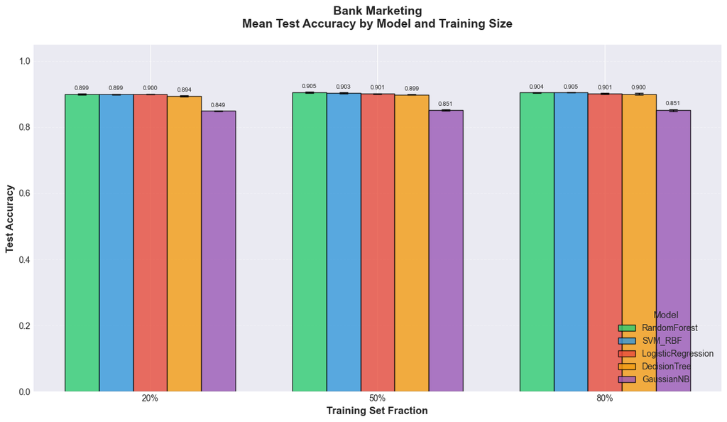

```
  ✓ Saved: fig1_Bank_Marketing_grouped_bars.png
```

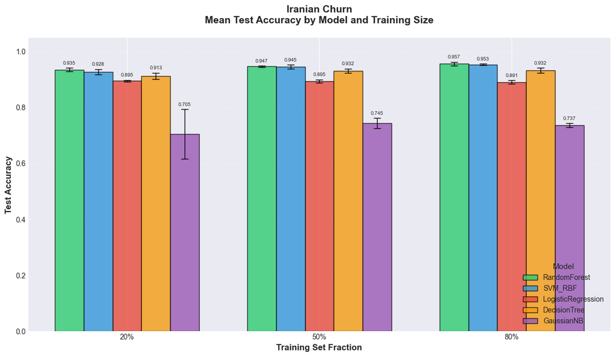

```
  ✓ Saved: fig1_Iranian_Churn_grouped_bars.png
```

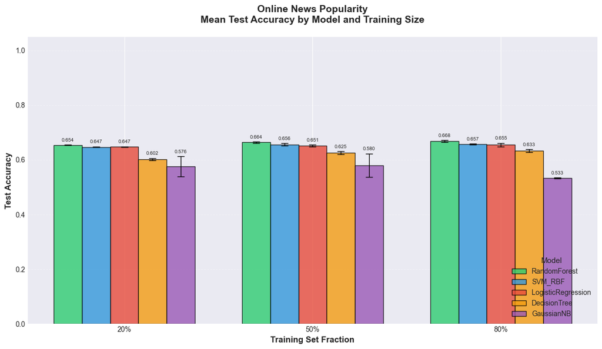

```
  ✓ Saved: fig1_Online_News_Popularity_grouped_bars.png
```

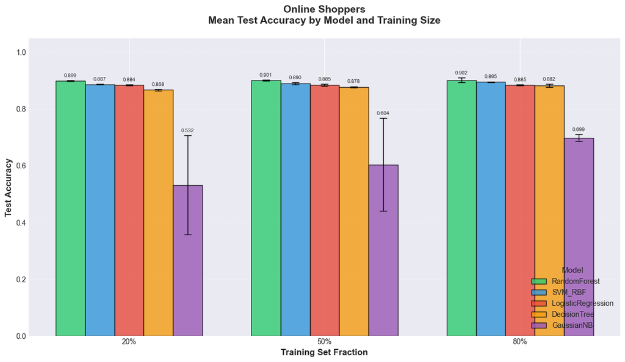

```
  ✓ Saved: fig1_Online_Shoppers_grouped_bars.png
```

```python
# Create figures directory if it doesn't exist
figures_dir = Path.cwd().parent / 'figures'
figures_dir.mkdir(exist_ok=True)
print(f"✓ Figures will be saved to: {figures_dir}")
print()

MODEL_ORDER = ['RandomForest', 'SVM_RBF', 'LogisticRegression', 'DecisionTree', 'GaussianNB']
MODEL_COLORS = {
    'RandomForest': '#2ecc71',
    'SVM_RBF': '#3498db',
    'LogisticRegression': '#e74c3c',
    'DecisionTree': '#f39c12',
    'GaussianNB': '#9b59b6'
}

print("=" * 80)
print("GENERATING VISUALIZATIONS")
print("=" * 80)
print()

# VISUALIZATION 1: Per-Dataset Grouped Bar Charts (Test Accuracy by Train Size)


for dataset_name in results_df['dataset'].unique():

    # Filter data for this dataset
    dataset_data = results_df[results_df['dataset'] == dataset_name]

    # Calculate mean and std for each model and train_size
    grouped = dataset_data.groupby(['train_size', 'model_name'])['test_acc'].agg(['mean', 'std']).reset_index()

    # Create figure
    fig, ax = plt.subplots(figsize=(12, 7))

    # Get unique train sizes and set up bar positions
    train_sizes = sorted(grouped['train_size'].unique())
    x = np.arange(len(train_sizes))
    width = 0.15  # Width of each bar

    # Plot bars for each model
    for i, model in enumerate(MODEL_ORDER):
        model_data = grouped[grouped['model_name'] == model]

        # Get means and stds in correct order
        means = [model_data[model_data['train_size'] == ts]['mean'].values[0]
                 if len(model_data[model_data['train_size'] == ts]) > 0 else 0
                 for ts in train_sizes]
        stds = [model_data[model_data['train_size'] == ts]['std'].values[0]
                if len(model_data[model_data['train_size'] == ts]) > 0 else 0
                for ts in train_sizes]

        # Plot bars with error bars
        offset = width * (i - 2)  # Center the groups
        ax.bar(x + offset, means, width, label=model,
               color=MODEL_COLORS[model], alpha=0.8, edgecolor='black', linewidth=1,
               yerr=stds, capsize=5, error_kw={'linewidth': 1.5, 'elinewidth': 1})

    # Formatting
    ax.set_xlabel('Training Set Fraction', fontsize=12, fontweight='bold')
    ax.set_ylabel('Test Accuracy', fontsize=12, fontweight='bold')
    ax.set_title(f'{dataset_name}\nMean Test Accuracy by Model and Training Size',
                 fontsize=14, fontweight='bold', pad=20)
    ax.set_xticks(x)
    ax.set_xticklabels([f'{ts:.0%}' for ts in train_sizes])
    ax.legend(title='Model', fontsize=10, title_fontsize=11, loc='lower right')
    ax.grid(axis='y', alpha=0.3, linestyle='--')
    ax.set_ylim([0, 1.05])



    for container in ax.containers:
        if isinstance(container, BarContainer):
            ax.bar_label(container, fmt='%.3f', fontsize=7, padding=3)

    plt.tight_layout()


    filename = f"fig1_{dataset_name.replace(' ', '_')}_grouped_bars.png"
    filepath = figures_dir / filename
    plt.savefig(filepath, dpi=300, bbox_inches='tight')

    plt.show()

    print(f" Saved: {filename}")
    plt.close()
    print()
```

```
Generating Visualization Set 2: Line Plots (Test Accuracy vs Train Size)
```

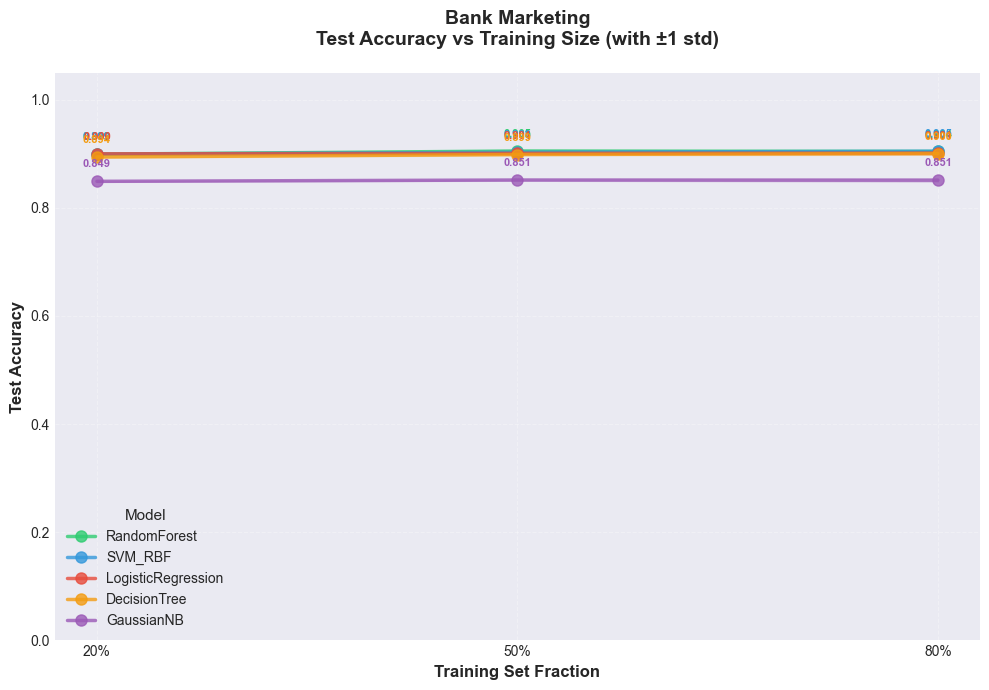

```
  ✓ Saved: fig2_Bank_Marketing_line_plot.png
```

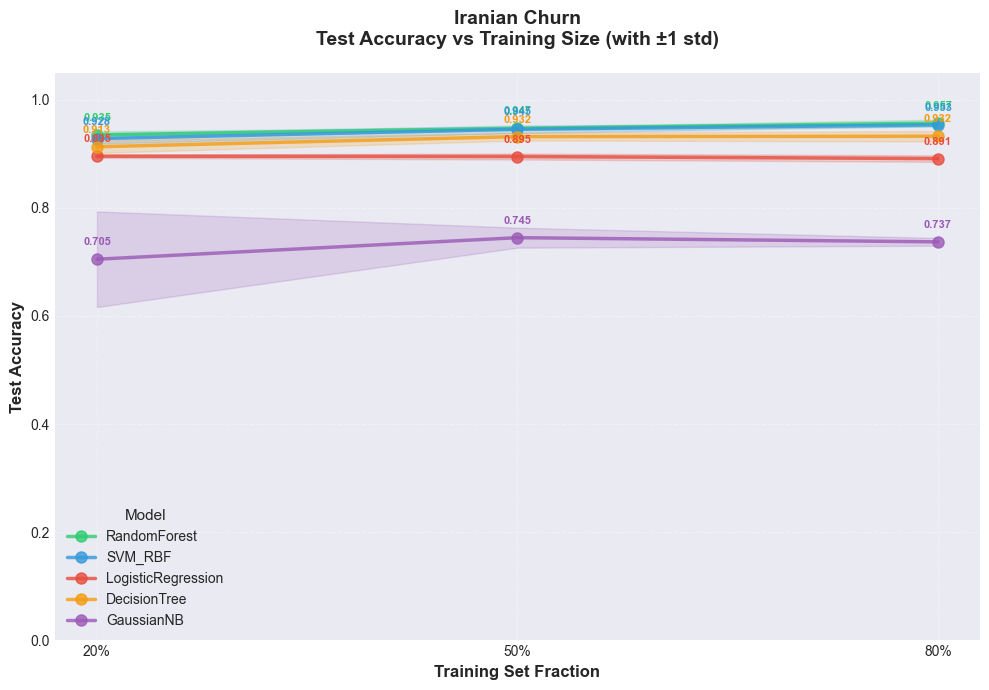

```
  ✓ Saved: fig2_Iranian_Churn_line_plot.png
```

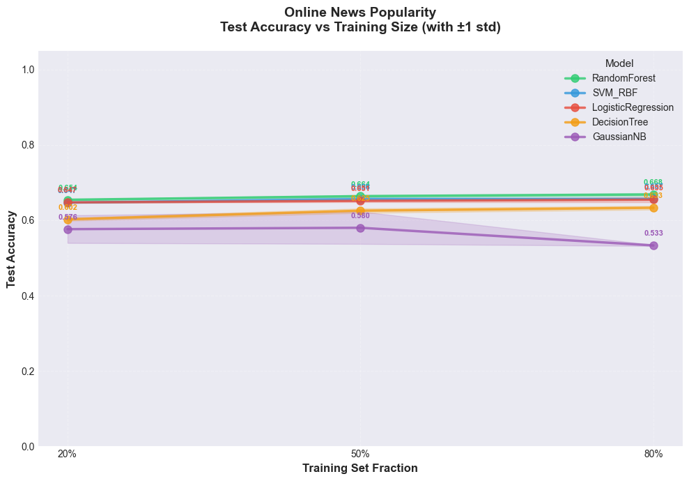

```
  ✓ Saved: fig2_Online_News_Popularity_line_plot.png
```

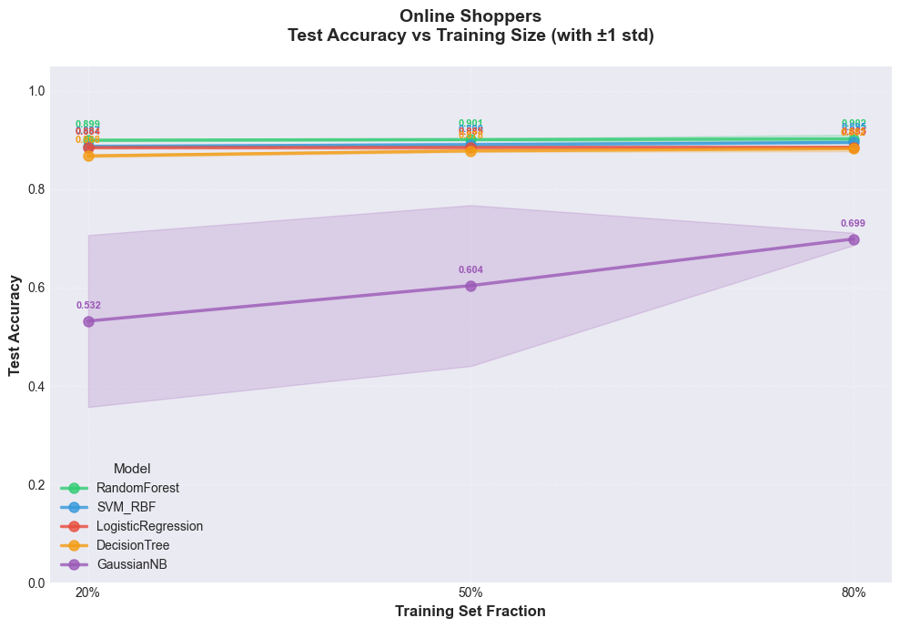

```
  ✓ Saved: fig2_Online_Shoppers_line_plot.png
```

```python
# VISUALIZATION SET 2: Per-Dataset Line Plots (Test Accuracy vs Train Size)

for dataset_name in results_df['dataset'].unique():

    # Filter data for this dataset
    dataset_data = results_df[results_df['dataset'] == dataset_name]

    # Calculate mean and std for each model and train_size
    grouped = dataset_data.groupby(['train_size', 'model_name'])['test_acc'].agg(['mean', 'std']).reset_index()

    # Create figure
    fig, ax = plt.subplots(figsize=(10, 7))

    # Plot line for each model
    for model in MODEL_ORDER:
        model_data = grouped[grouped['model_name'] == model].sort_values('train_size')

        # Plot line with markers
        ax.plot(model_data['train_size'], model_data['mean'],
                marker='o', markersize=8, linewidth=2.5,
                label=model, color=MODEL_COLORS[model], alpha=0.8)

        # Add error bars
        ax.fill_between(model_data['train_size'],
                        model_data['mean'] - model_data['std'],
                        model_data['mean'] + model_data['std'],
                        alpha=0.2, color=MODEL_COLORS[model])

        # Add value labels at each point
        for _, row in model_data.iterrows():
            ax.annotate(f'{row["mean"]:.3f}',
                       xy=(row['train_size'], row['mean']),
                       xytext=(0, 10), textcoords='offset points',
                       ha='center', fontsize=8, fontweight='bold',
                       color=MODEL_COLORS[model])

    # Formatting
    ax.set_xlabel('Training Set Fraction', fontsize=12, fontweight='bold')
    ax.set_ylabel('Test Accuracy', fontsize=12, fontweight='bold')
    ax.set_title(f'{dataset_name}\nTest Accuracy vs Training Size (with ±1 std)',
                 fontsize=14, fontweight='bold', pad=20)
    ax.set_xticks([0.2, 0.5, 0.8])
    ax.set_xticklabels(['20%', '50%', '80%'])
    ax.legend(title='Model', fontsize=10, title_fontsize=11, loc='best')
    ax.grid(True, alpha=0.3, linestyle='--')
    ax.set_ylim([0, 1.05])

    plt.tight_layout()

    # Save figure
    filename = f"fig2_{dataset_name.replace(' ', '_')}_line_plot.png"
    filepath = figures_dir / filename
    plt.savefig(filepath, dpi=300, bbox_inches='tight')

    plt.show()

    print(f" Saved: {filename}")
    plt.close()
    print()
```

```
Generating Visualization Set 3: Train vs CV vs Test Comparison (train_size=0.8)
```

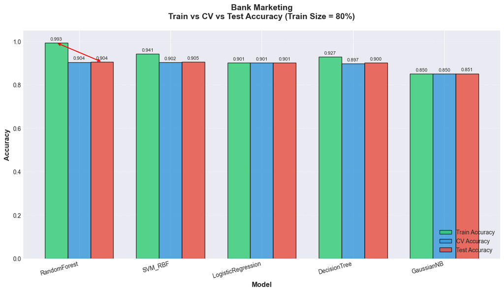

```
  ✓ Saved: fig3_Bank_Marketing_train_cv_test.png
```

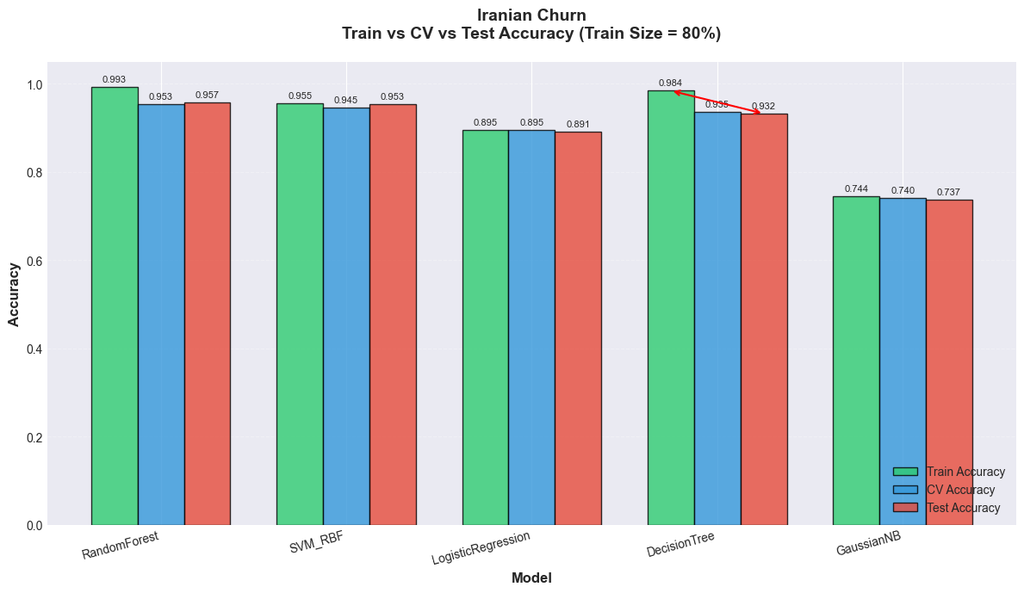

```
  ✓ Saved: fig3_Iranian_Churn_train_cv_test.png
```

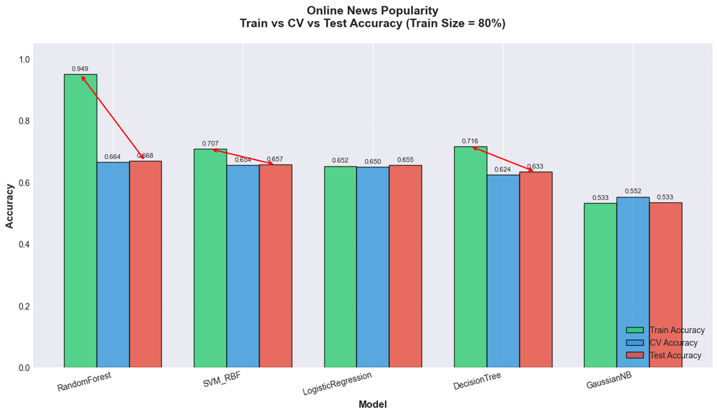

```
  ✓ Saved: fig3_Online_News_Popularity_train_cv_test.png
```

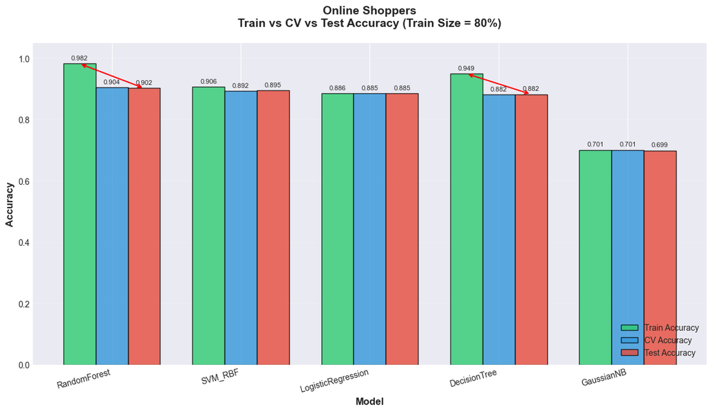

```
  ✓ Saved: fig3_Online_Shoppers_train_cv_test.png
```

```python
# VISUALIZATION SET 3: Train vs CV vs Test Accuracy (at train_size=0.8)

print("Generating Visualization Set 3: Train vs CV vs Test Comparison (train_size=0.8)")

for dataset_name in results_df['dataset'].unique():

    # Filter data for this dataset at train_size=0.8
    dataset_data = results_df[(results_df['dataset'] == dataset_name) &
                              (results_df['train_size'] == 0.8)]

    # Calculate mean for train, cv, and test accuracies
    train_means = dataset_data.groupby('model_name')['train_acc'].mean()
    cv_means = dataset_data.groupby('model_name')['cv_acc'].mean()
    test_means = dataset_data.groupby('model_name')['test_acc'].mean()

    # Create figure
    fig, ax = plt.subplots(figsize=(12, 7))

    # Set up bar positions
    x = np.arange(len(MODEL_ORDER))
    width = 0.25

    # Plot bars for each accuracy type
    train_bars = ax.bar(x - width, [train_means.get(m, 0) for m in MODEL_ORDER],
                        width, label='Train Accuracy',
                        color='#2ecc71', alpha=0.8, edgecolor='black', linewidth=1)

    cv_bars = ax.bar(x, [cv_means.get(m, 0) for m in MODEL_ORDER],
                     width, label='CV Accuracy',
                     color='#3498db', alpha=0.8, edgecolor='black', linewidth=1)

    test_bars = ax.bar(x + width, [test_means.get(m, 0) for m in MODEL_ORDER],
                       width, label='Test Accuracy',
                       color='#e74c3c', alpha=0.8, edgecolor='black', linewidth=1)

    # Formatting
    ax.set_xlabel('Model', fontsize=12, fontweight='bold')
    ax.set_ylabel('Accuracy', fontsize=12, fontweight='bold')
    ax.set_title(f'{dataset_name}\nTrain vs CV vs Test Accuracy (Train Size = 80%)',
                 fontsize=14, fontweight='bold', pad=20)
    ax.set_xticks(x)
    ax.set_xticklabels(MODEL_ORDER, rotation=15, ha='right')
    ax.legend(fontsize=10, loc='lower right')
    ax.grid(axis='y', alpha=0.3, linestyle='--')
    ax.set_ylim([0, 1.05])

    # Add value labels on bars
    for bars in [train_bars, cv_bars, test_bars]:
        ax.bar_label(bars, fmt='%.3f', fontsize=8, padding=3)

    # Add annotation about overfitting
    for i, model in enumerate(MODEL_ORDER):
        train_val = train_means.get(model, 0)
        test_val = test_means.get(model, 0)
        gap = train_val - test_val

        if gap > 0.05:  # Significant overfitting
            ax.annotate('', xy=(x[i] + width, test_val),
                       xytext=(x[i] - width, train_val),
                       arrowprops=dict(arrowstyle='<->', color='red', lw=1.5))

    plt.tight_layout()

    # Save figure FIRST (before show clears it)
    filename = f"fig3_{dataset_name.replace(' ', '_')}_train_cv_test.png"
    filepath = figures_dir / filename
    plt.savefig(filepath, dpi=300, bbox_inches='tight')

    plt.show()

    print(f" Saved: {filename}")
    plt.close()
    print()
```

```
Generating Visualization Set 4: Heatmap (Datasets × Models)
  Using train_size=0.8 for consistency
```

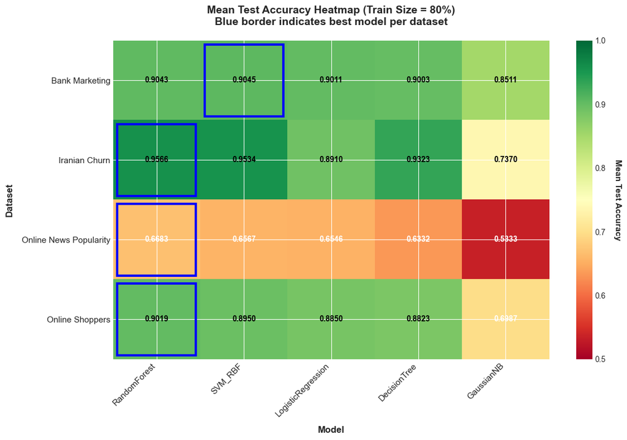

[output not shown]

```python
# VISUALIZATION SET 4: Heatmap of Mean Test Accuracy (Datasets × Models)

print("Generating Visualization Set 4: Heatmap (Datasets × Models)")
print("  Using train_size=0.8 for consistency")

# Filter for train_size=0.8 only
heatmap_data = results_df[results_df['train_size'] == 0.8]

# Calculate mean test accuracy for each dataset-model combination
heatmap_pivot = heatmap_data.groupby(['dataset', 'model_name'])['test_acc'].mean().reset_index()
heatmap_matrix = heatmap_pivot.pivot(index='dataset', columns='model_name', values='test_acc')

# Reorder columns to match MODEL_ORDER
heatmap_matrix = heatmap_matrix[MODEL_ORDER]

# Create figure
fig, ax = plt.subplots(figsize=(12, 8))

# Create heatmap using imshow
im = ax.imshow(heatmap_matrix.values, cmap='RdYlGn', aspect='auto', vmin=0.5, vmax=1.0)

# Set ticks and labels
ax.set_xticks(np.arange(len(MODEL_ORDER)))
ax.set_yticks(np.arange(len(heatmap_matrix.index)))
ax.set_xticklabels(MODEL_ORDER, rotation=45, ha='right', fontsize=11)
ax.set_yticklabels(heatmap_matrix.index, fontsize=11)

# Add colorbar
cbar = plt.colorbar(im, ax=ax)
cbar.set_label('Mean Test Accuracy', rotation=270, labelpad=20, fontsize=11, fontweight='bold')

# Annotate cells with values
for i in range(len(heatmap_matrix.index)):
    for j in range(len(MODEL_ORDER)):
        value = heatmap_matrix.values[i, j]

        # Determine text color based on background
        text_color = 'white' if value < 0.7 else 'black'

        # Add value
        text = ax.text(j, i, f'{value:.4f}',
                      ha='center', va='center', color=text_color,
                      fontsize=10, fontweight='bold')

        # Highlight best model per dataset with border
        if value == heatmap_matrix.iloc[i].max():
            rect = plt.Rectangle((j-0.45, i-0.45), 0.9, 0.9,
                                fill=False, edgecolor='blue', linewidth=3)
            ax.add_patch(rect)

# Formatting
ax.set_xlabel('Model', fontsize=12, fontweight='bold', labelpad=10)
ax.set_ylabel('Dataset', fontsize=12, fontweight='bold', labelpad=10)
ax.set_title('Mean Test Accuracy Heatmap (Train Size = 80%)\nBlue border indicates best model per dataset',
             fontsize=14, fontweight='bold', pad=20)

plt.tight_layout()

# Save figure FIRST (before show clears it)
filename = "fig4_heatmap_test_accuracy.png"
filepath = figures_dir / filename
plt.savefig(filepath, dpi=300, bbox_inches='tight')

# Display in notebook
plt.show()

print(f" Saved: {filename}")
plt.close()

print()
```

## 8. Advanced Evaluation Metrics (Supplementary)

**Purpose**: This section provides additional evaluation metrics beyond accuracy to better understand model performance, especially for datasets with class imbalance.

**Important Notes**:

**Metrics Computed**:

1. **Precision**: Of all positive predictions, how many were correct? (Minimizes false positives)
2. **Recall**: Of all actual positives, how many did we find? (Minimizes false negatives)
3. **F1-Score**: Harmonic mean of precision and recall (balanced metric)
4. **Confusion Matrix**: Detailed breakdown of correct/incorrect predictions by class
5. **ROC-AUC**: Area under ROC curve (requires probability estimates, measures ranking quality)

```python
from sklearn.metrics import precision_score, recall_score, f1_score, confusion_matrix, roc_auc_score, roc_curve
from sklearn.metrics import ConfusionMatrixDisplay
import warnings
warnings.filterwarnings('ignore')

print("=" * 80)
print("ADVANCED EVALUATION METRICS (Supplementary Analysis)")
print("=" * 80)
print("Using train_size=0.8, repeat=0 (best models from 80/20 split)")
print()

# Function to evaluate a single model on test data
def evaluate_model_advanced(model_name, best_model, X_test, y_test):
    """
    Compute advanced metrics using already-trained model.

    Parameters:
    -----------
    model_name : str
        Name of the model
    best_model : fitted estimator
        Already-trained model from GridSearchCV/RandomizedSearchCV
    X_test : array-like
        Test features
    y_test : array-like
        True test labels

    Returns:
    --------
    metrics : dict
        Dictionary of computed metrics
    """
    # Get predictions
    y_pred = best_model.predict(X_test)

    # Determine unique classes and positive label
    unique_classes = np.unique(y_test)

    # For binary classification, detect positive label
    # Convention: 'yes', 'true', '1', 1, or the second class alphabetically
    if len(unique_classes) == 2:
        # Try to identify positive class intelligently
        str_classes = [str(c).lower() for c in unique_classes]
        if 'yes' in str_classes:
            pos_label = unique_classes[str_classes.index('yes')]
        elif 'true' in str_classes:
            pos_label = unique_classes[str_classes.index('true')]
        elif '1' in str_classes or 1 in unique_classes:
            pos_label = 1 if 1 in unique_classes else '1'
        else:
            # Default: use the second class (alphabetically last for strings)
            pos_label = sorted(unique_classes)[1]
    else:
        # Multi-class: we'll use 'macro' averaging
        pos_label = None

    # Compute basic metrics (using binary classification)
    # Note: For multi-class, we'd use 'macro' or 'weighted' averaging
    if len(unique_classes) == 2:
        precision = precision_score(y_test, y_pred, average='binary', pos_label=pos_label, zero_division=0)
        recall = recall_score(y_test, y_pred, average='binary', pos_label=pos_label, zero_division=0)
        f1 = f1_score(y_test, y_pred, average='binary', pos_label=pos_label, zero_division=0)
    else:
        # Multi-class case
        precision = precision_score(y_test, y_pred, average='macro', zero_division=0)
        recall = recall_score(y_test, y_pred, average='macro', zero_division=0)
        f1 = f1_score(y_test, y_pred, average='macro', zero_division=0)

    # Compute confusion matrix
    cm = confusion_matrix(y_test, y_pred)

    # Try to compute ROC-AUC if model supports probability estimates
    roc_auc = None
    y_proba = None

    if hasattr(best_model, 'predict_proba'):
        try:
            # For binary classification, get probability of positive class
            if len(unique_classes) == 2:
                # Find index of positive class in classes_
                classes = best_model.classes_
                pos_idx = np.where(classes == pos_label)[0][0]
                y_proba = best_model.predict_proba(X_test)[:, pos_idx]
            else:
                # For multi-class, use one-vs-rest approach
                y_proba = best_model.predict_proba(X_test)

            # Compute ROC-AUC
            if len(unique_classes) == 2:
                roc_auc = roc_auc_score(y_test, y_proba)
            else:
                # Multi-class ROC-AUC using ovr (one-vs-rest)
                roc_auc = roc_auc_score(y_test, y_proba, multi_class='ovr', average='macro')
        except Exception as e:
            pass  # Some models may not support this even with predict_proba

    return {
        'model_name': model_name,
        'precision': precision,
        'recall': recall,
        'f1_score': f1,
        'confusion_matrix': cm,
        'roc_auc': roc_auc,
        'y_proba': y_proba,
        'y_pred': y_pred,
        'pos_label': pos_label
    }

# Store results for each dataset
advanced_results = {}

# Process each dataset
for dataset_name, (X, y) in datasets.items():

    print(f"\n{'=' * 80}")
    print(f"DATASET: {dataset_name}")
    print(f"{'=' * 80}\n")

    # Extract target values
    if isinstance(y, pd.DataFrame):
        y_values = y.iloc[:, 0].values
    else:
        y_values = y.values

    # Use train_size=0.8 and seed=42 (same as repeat=0)
    X_train, X_test, y_train, y_test = train_test_split(
        X, y_values,
        train_size=0.8,
        random_state=42,  # Same seed as repeat=0
        stratify=y_values
    )

    # Build preprocessor and model specs for this dataset
    preprocessor = make_preprocessor(X)
    model_specs = build_model_specs(preprocessor, memory=memory)

    dataset_results = []

    # Evaluate each model
    for model_name, specs in model_specs.items():

        print(f"{model_name}:")

        # Get pipeline and hyperparameters
        pipeline = specs['pipeline']
        param_grid = specs['param_grid']
        search_method = specs.get('search_method', 'grid')

        # Create and fit the search (reusing same approach as experiments)
        cv = StratifiedKFold(n_splits=3, shuffle=True, random_state=42)

        if search_method == 'random':
            n_iter = specs.get('n_iter', 10)
            search = RandomizedSearchCV(
                pipeline, param_grid,
                n_iter=n_iter,
                cv=cv,
                scoring='accuracy',
                n_jobs=-1,
                random_state=42
            )
        else:
            search = GridSearchCV(
                pipeline, param_grid,
                cv=cv,
                scoring='accuracy',
                n_jobs=-1
            )

        # Fit on training data (this recreates the best model)
        search.fit(X_train, y_train)
        best_model = search.best_estimator_

        # Evaluate using advanced metrics
        metrics = evaluate_model_advanced(model_name, best_model, X_test, y_test)
        dataset_results.append(metrics)

        # Display metrics
        print(f"  Precision: {metrics['precision']:.4f}")
        print(f"  Recall:    {metrics['recall']:.4f}")
        print(f"  F1-Score:  {metrics['f1_score']:.4f}")

        if metrics['roc_auc'] is not None:
            print(f"  ROC-AUC:   {metrics['roc_auc']:.4f}")
        else:
            print(f"  ROC-AUC:   N/A (model does not support probability estimates)")

        print()

    advanced_results[dataset_name] = dataset_results

print("=" * 80)
print("✓ Advanced metrics computed for all models")
print("=" * 80)
```

[output not shown]

[output cut: 230 more lines]

[output not shown]

```
================================================================================
CONFUSION MATRICES (80/20 split)
================================================================================


Bank Marketing
--------------------------------------------------------------------------------
```

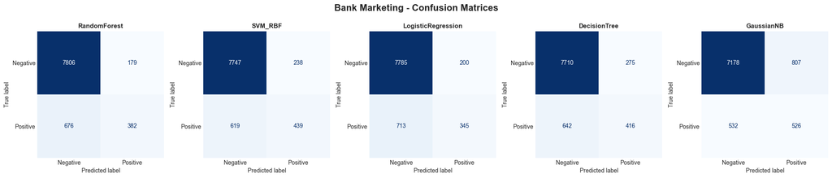

```
✓ Saved: fig_cm_Bank_Marketing_confusion_matrices.png

Online Shoppers
--------------------------------------------------------------------------------
```

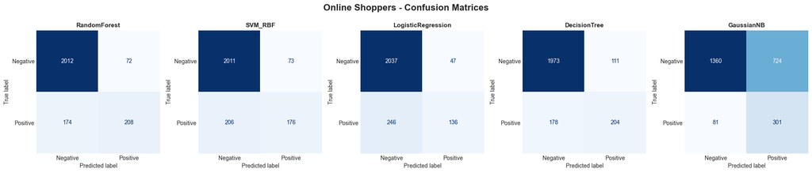

```
✓ Saved: fig_cm_Online_Shoppers_confusion_matrices.png

Iranian Churn
--------------------------------------------------------------------------------
```

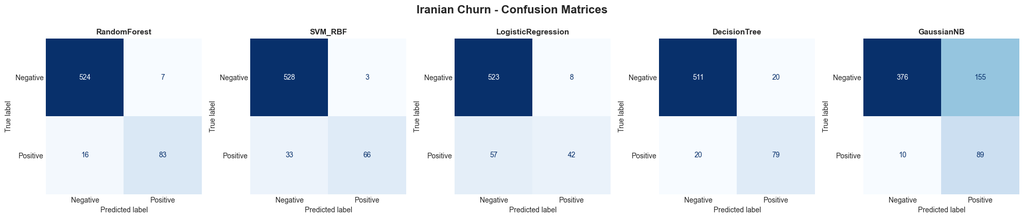

```
✓ Saved: fig_cm_Iranian_Churn_confusion_matrices.png

Online News Popularity
--------------------------------------------------------------------------------
```

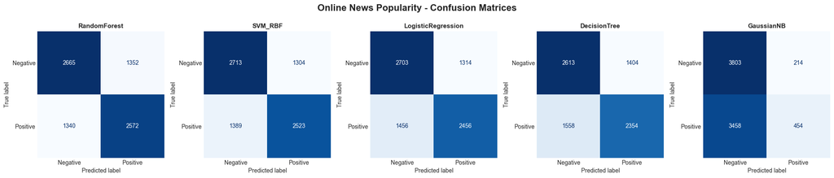

```
✓ Saved: fig_cm_Online_News_Popularity_confusion_matrices.png

================================================================================
```

```python
# ============================================================================
# CONFUSION MATRICES
# ============================================================================

print("\n" + "=" * 80)
print("CONFUSION MATRICES (80/20 split)")
print("=" * 80)
print()

for dataset_name, results in advanced_results.items():

    print(f"\n{dataset_name}")
    print("-" * 80)

    # Create subplots for all models
    fig, axes = plt.subplots(1, len(MODEL_ORDER), figsize=(20, 4))
    fig.suptitle(f'{dataset_name} - Confusion Matrices', fontsize=16, fontweight='bold', y=1.02)

    for idx, model_name in enumerate(MODEL_ORDER):
        # Find the results for this model
        model_result = next((r for r in results if r['model_name'] == model_name), None)

        if model_result:
            cm = model_result['confusion_matrix']

            # Determine number of classes from confusion matrix shape
            n_classes = cm.shape[0]

            # Create appropriate labels based on number of classes
            if n_classes == 2:
                # Binary classification
                display_labels = ['Negative', 'Positive']
            else:
                # Multi-class classification
                display_labels = [f'Class {i}' for i in range(n_classes)]

            # Display confusion matrix
            disp = ConfusionMatrixDisplay(confusion_matrix=cm, display_labels=display_labels)
            disp.plot(ax=axes[idx], cmap='Blues', colorbar=False)
            axes[idx].set_title(model_name, fontsize=11, fontweight='bold')
            axes[idx].grid(False)

    plt.tight_layout()

    # Save figure FIRST (before show clears it)
    filename = f"fig_cm_{dataset_name.replace(' ', '_')}_confusion_matrices.png"
    filepath = figures_dir / filename
    plt.savefig(filepath, dpi=300, bbox_inches='tight')

    # Display in notebook
    plt.show()

    print(f"✓ Saved: {filename}")
    plt.close()

print("\n" + "=" * 80)
```

```
================================================================================
ROC CURVES (80/20 split)
================================================================================


Bank Marketing
--------------------------------------------------------------------------------
```

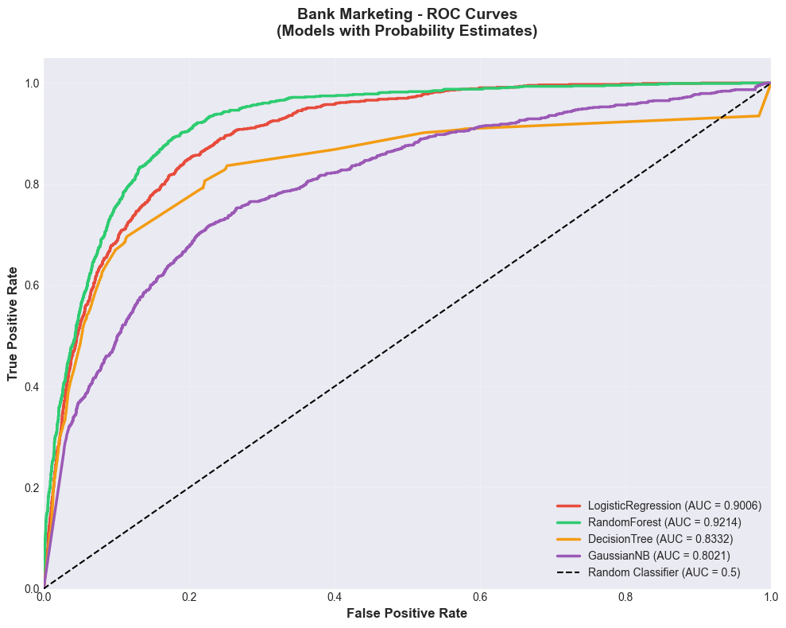

[output not shown]

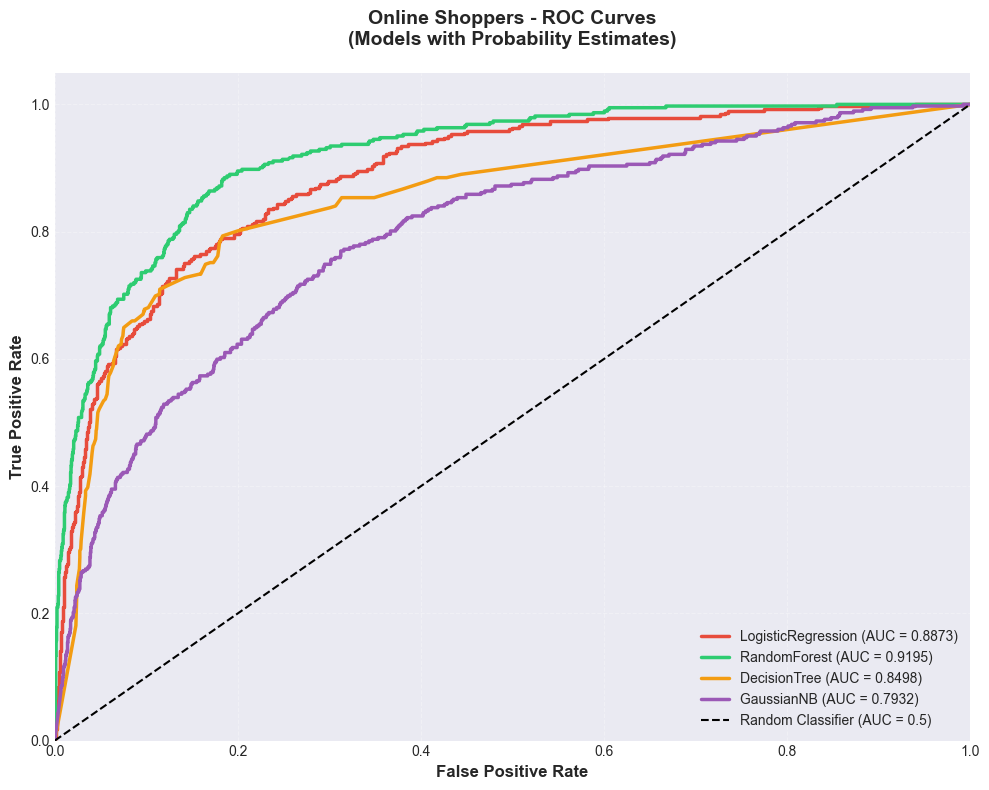

[output not shown]

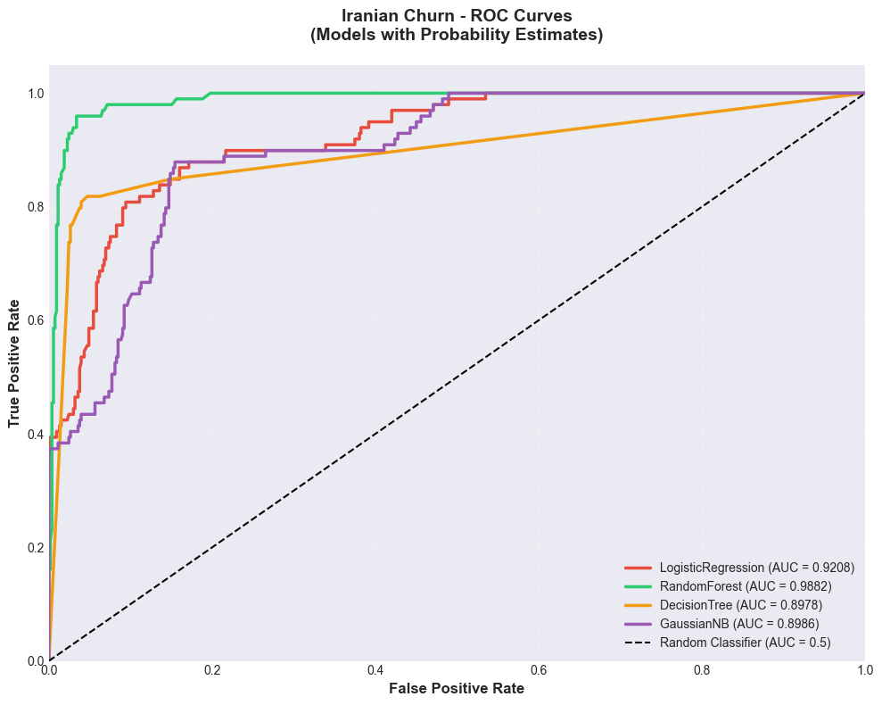

[output not shown]

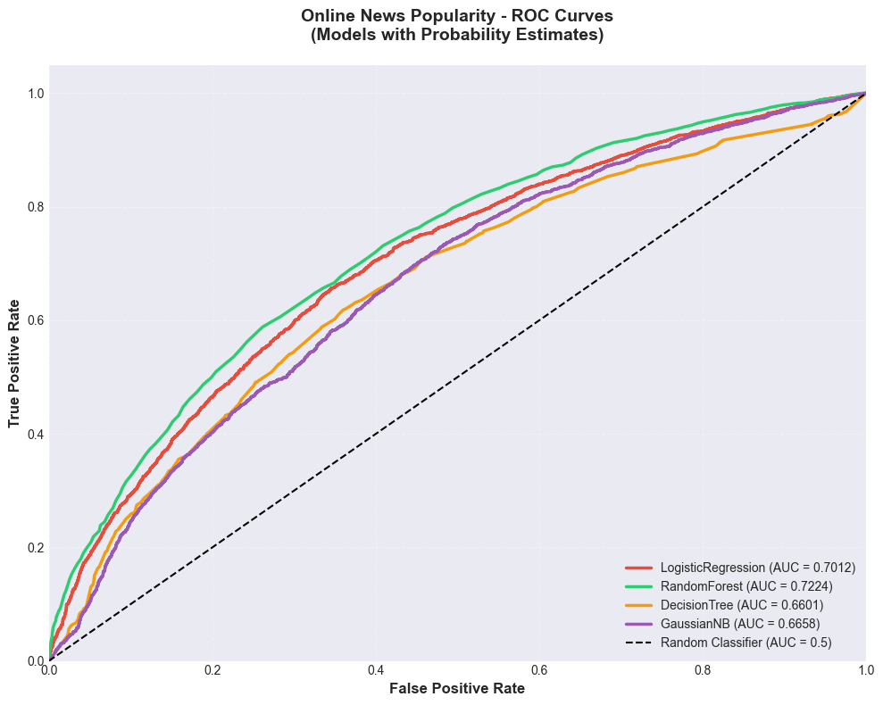

[output not shown]

```python
# ============================================================================
# ROC CURVES
# ============================================================================

print("\n" + "=" * 80)
print("ROC CURVES (80/20 split)")
print("=" * 80)
print()

for dataset_name, results in advanced_results.items():

    print(f"\n{dataset_name}")
    print("-" * 80)

    # Create figure for ROC curves
    fig, ax = plt.subplots(figsize=(10, 8))

    # Plot ROC curve for each model that supports it
    models_with_roc = 0

    for model_result in results:
        model_name = model_result['model_name']

        if model_result['roc_auc'] is not None and model_result['y_proba'] is not None:
            # Get y_test for this dataset
            dataset_X, dataset_y = datasets[dataset_name]
            if isinstance(dataset_y, pd.DataFrame):
                y_values = dataset_y.iloc[:, 0].values
            else:
                y_values = dataset_y.values

            _, _, _, y_test = train_test_split(
                dataset_X, y_values,
                train_size=0.8,
                random_state=42,
                stratify=y_values
            )

            # Get the positive label used for this model
            pos_label = model_result.get('pos_label', None)

            # Compute ROC curve
            # For binary classification with string labels, need to specify pos_label
            if pos_label is not None:
                fpr, tpr, _ = roc_curve(y_test, model_result['y_proba'], pos_label=pos_label)
            else:
                # Multi-class case - skip ROC curve (would need one-vs-rest approach)
                continue

            # Plot
            ax.plot(fpr, tpr, linewidth=2.5,
                   label=f"{model_name} (AUC = {model_result['roc_auc']:.4f})",
                   color=MODEL_COLORS[model_name])

            models_with_roc += 1

    # Plot diagonal reference line
    ax.plot([0, 1], [0, 1], 'k--', linewidth=1.5, label='Random Classifier (AUC = 0.5)')

    # Formatting
    ax.set_xlabel('False Positive Rate', fontsize=12, fontweight='bold')
    ax.set_ylabel('True Positive Rate', fontsize=12, fontweight='bold')
    ax.set_title(f'{dataset_name} - ROC Curves\n(Models with Probability Estimates)',
                fontsize=14, fontweight='bold', pad=20)
    ax.legend(loc='lower right', fontsize=10)
    ax.grid(True, alpha=0.3, linestyle='--')
    ax.set_xlim([0, 1])
    ax.set_ylim([0, 1.05])

    if models_with_roc == 0:
        ax.text(0.5, 0.5, 'No models with probability estimates available',
               ha='center', va='center', fontsize=14, color='red')

    plt.tight_layout()

    # Save figure FIRST (before show clears it)
    filename = f"fig_roc_{dataset_name.replace(' ', '_')}_roc_curves.png"
    filepath = figures_dir / filename
    plt.savefig(filepath, dpi=300, bbox_inches='tight')

    # Display in notebook
    plt.show()

    print(f"✓ Saved: {filename}")

    if models_with_roc < len(MODEL_ORDER):
        print(f"  Note: {len(MODEL_ORDER) - models_with_roc} model(s) without probability estimates")
        print(f"  (SVM with probability=False and DecisionTree don't support predict_proba in this setup)")

    plt.close()

print("\n" + "=" * 80)
print("✓ All supplementary evaluation metrics completed!")
print("=" * 80)
print()
print("Summary of additional figures generated:")
print("  • Confusion matrices: 4 plots (one per dataset)")
print("  • ROC curves: 4 plots (one per dataset)")
print(f"  Additional figures: 8 PNG files")
print("=" * 80)
```

## 9. Feature Importance Analysis (Interpretability)

**Purpose**: Understand which features contribute most to Random Forest predictions, providing interpretability for the best-performing model.

**Important Notes**:

- **Why Random Forest?** Tree-based models like Random Forest naturally provide feature importance scores based on how much each feature reduces impurity (Gini or entropy) across all trees in the ensemble.
- **Limitations of Impurity-Based Importance**:
  - Biased toward high-cardinality features (features with many categories)
  - Can be misleading with correlated features
  - Measures predictive utility, NOT causal relationships
  - One-hot encoded features may split importance across multiple indicator variables
- **Interpretation**: High importance means the feature is useful for splitting the data to make accurate predictions, but this does NOT imply causation or that changing the feature will change the outcome.

[output not shown]

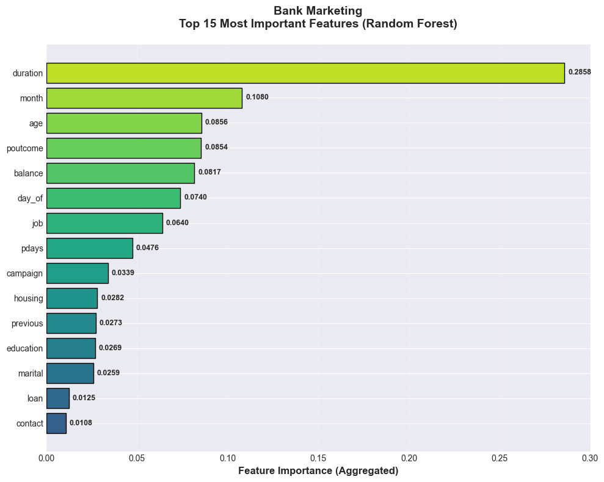

[output not shown]

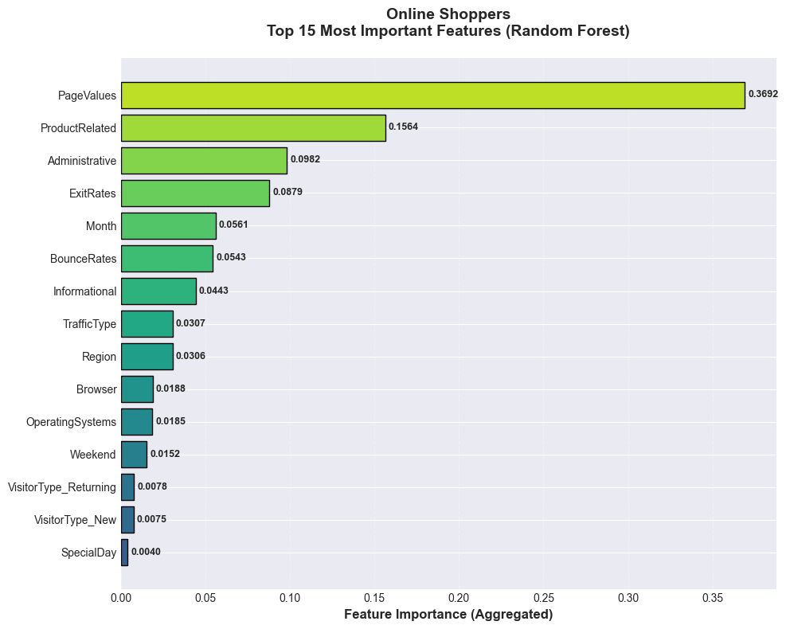

[output not shown]

```python
print("=" * 80)
print("FEATURE IMPORTANCE ANALYSIS (Random Forest)")
print("=" * 80)
print("Using best Random Forest model from 80/20 split")
print("Analyzing 2 representative datasets: Bank Marketing and Online Shoppers")
print()

# Select representative datasets for analysis
datasets_to_analyze = ['Bank Marketing', 'Online Shoppers']

def get_feature_names_from_preprocessor(preprocessor, X):
    """
    Extract feature names after preprocessing, including one-hot encoded features.

    Parameters:
    -----------
    preprocessor : ColumnTransformer
        Fitted preprocessing pipeline
    X : DataFrame
        Original feature DataFrame

    Returns:
    --------
    feature_names : list
        List of feature names after preprocessing
    """
    feature_names = []

    # Get the transformers from ColumnTransformer
    for name, transformer, columns in preprocessor.transformers_:
        if name == 'num':
            # Numeric features - names unchanged
            feature_names.extend(columns)
        elif name == 'cat':
            # Categorical features - one-hot encoded
            # Get the OneHotEncoder
            ohe = transformer.named_steps['onehot']

            # For each categorical column, get the encoded feature names
            for i, col in enumerate(columns):
                # Get categories for this column
                categories = ohe.categories_[i]
                # Create feature names like "feature_category"
                for cat in categories:
                    feature_names.append(f"{col}_{cat}")

    return feature_names

def aggregate_onehot_importance(feature_names, importances):
    """
    Aggregate feature importance for one-hot encoded features back to original features.

    Parameters:
    -----------
    feature_names : list
        List of all feature names (including one-hot encoded)
    importances : array
        Feature importance scores

    Returns:
    --------
    aggregated_dict : dict
        Dictionary mapping original feature names to aggregated importance
    """
    importance_dict = {}

    for feat, imp in zip(feature_names, importances):
        # Check if feature is one-hot encoded (contains underscore)
        if '_' in feat and not feat.startswith('_'):
            # Extract original feature name (everything before last underscore)
            parts = feat.rsplit('_', 1)
            if len(parts) == 2:
                original_feat = parts[0]
            else:
                original_feat = feat
        else:
            original_feat = feat

        # Aggregate importance
        if original_feat in importance_dict:
            importance_dict[original_feat] += imp
        else:
            importance_dict[original_feat] = imp

    return importance_dict

# Analyze each selected dataset
for dataset_name in datasets_to_analyze:

    print(f"\n{'=' * 80}")
    print(f"DATASET: {dataset_name}")
    print(f"{'=' * 80}\n")

    # Get dataset
    X, y = datasets[dataset_name]

    # Extract target values
    if isinstance(y, pd.DataFrame):
        y_values = y.iloc[:, 0].values
    else:
        y_values = y.values

    # Split data (80/20, same as experiments)
    X_train, X_test, y_train, y_test = train_test_split(
        X, y_values,
        train_size=0.8,
        random_state=42,
        stratify=y_values
    )

    # Build preprocessor and model specs
    preprocessor = make_preprocessor(X)
    model_specs = build_model_specs(preprocessor, memory=memory)

    # Get Random Forest specification
    rf_spec = model_specs['RandomForest']
    pipeline = rf_spec['pipeline']
    param_grid = rf_spec['param_grid']

    # Train Random Forest with RandomizedSearchCV (same as experiments)
    cv = StratifiedKFold(n_splits=3, shuffle=True, random_state=42)
    search = RandomizedSearchCV(
        pipeline, param_grid,
        n_iter=8,  # Same as in experiments
        cv=cv,
        scoring='accuracy',
        n_jobs=-1,
        random_state=42
    )

    print("Training Random Forest to extract feature importance...")
    search.fit(X_train, y_train)
    best_rf = search.best_estimator_
    print(f"✓ Training complete. Best params: {search.best_params_}")
    print()

    # Extract the Random Forest model from the pipeline
    # Pipeline structure: [('preprocess', ...), ('model', RandomForest)]
    rf_model = best_rf.named_steps['model']

    # Get feature importances
    importances = rf_model.feature_importances_

    # Get feature names after preprocessing
    fitted_preprocessor = best_rf.named_steps['preprocess']
    feature_names = get_feature_names_from_preprocessor(fitted_preprocessor, X_train)

    print(f"Total features after preprocessing: {len(feature_names)}")
    print(f"  (Original features: {X.shape[1]})")
    print()

    # Aggregate one-hot encoded features
    aggregated_importance = aggregate_onehot_importance(feature_names, importances)

    # Sort by importance
    sorted_features = sorted(aggregated_importance.items(), key=lambda x: x[1], reverse=True)

    # Display top 15 features
    print("Top 15 Most Important Features (aggregated):")
    print("-" * 60)
    for i, (feat, imp) in enumerate(sorted_features[:15], 1):
        print(f"{i:2d}. {feat:40s} {imp:.4f} ({imp*100:.2f}%)")
    print()

    # Create horizontal bar chart
    top_n = 15
    top_features = sorted_features[:top_n]
    feat_names = [f[0] for f in top_features]
    feat_importance = [f[1] for f in top_features]

    # Reverse for plotting (highest at top)
    feat_names = feat_names[::-1]
    feat_importance = feat_importance[::-1]

    fig, ax = plt.subplots(figsize=(10, 8))

    # Create horizontal bars
    colors = plt.cm.viridis(np.linspace(0.3, 0.9, top_n))
    bars = ax.barh(range(top_n), feat_importance, color=colors, edgecolor='black', linewidth=1)

    # Formatting
    ax.set_yticks(range(top_n))
    ax.set_yticklabels(feat_names, fontsize=10)
    ax.set_xlabel('Feature Importance (Aggregated)', fontsize=12, fontweight='bold')
    ax.set_title(f'{dataset_name}\nTop {top_n} Most Important Features (Random Forest)',
                fontsize=14, fontweight='bold', pad=20)
    ax.grid(axis='x', alpha=0.3, linestyle='--')

    # Add value labels
    for i, (bar, val) in enumerate(zip(bars, feat_importance)):
        ax.text(val + 0.002, i, f'{val:.4f}',
               va='center', fontsize=9, fontweight='bold')

    plt.tight_layout()

    # Save figure FIRST (before show clears it)
    filename = f"fig_fi_{dataset_name.replace(' ', '_')}_feature_importance.png"
    filepath = figures_dir / filename
    plt.savefig(filepath, dpi=300, bbox_inches='tight')

    # Display in notebook
    plt.show()

    print(f"✓ Saved: {filename}")
    plt.close()

    print()

print("=" * 80)
print("✓ Feature importance analysis completed!")
print("=" * 80)
print()
print("Key Insights:")
print("  • Feature importance shows which features are most useful for predictions")
print("  • One-hot encoded features are aggregated back to their original groups")
print("  • High importance ≠ causation (just predictive utility)")
print("  • Results are model-specific and may differ for other algorithms")
print("  • Useful for understanding model decisions and domain insights")
print("=" * 80)
```

## 10. Discussion

Answer the following questions based on the experimental results:

### 10.1 Overall Winner

**Which classifier performs best on average across all datasets and training sizes?**

- Consider both mean accuracy and consistency (low standard deviation)
- Is there a clear winner or are results dataset-dependent?

### 10.2 Training Size Effects

**How does training set size affect different models?**

- Which models benefit most from additional training data?
- Which models plateau quickly?
- Are there models that show signs of overfitting with more data?

### 10.3 Overfitting vs Underfitting

**Which models show evidence of overfitting or underfitting?**

- Overfitting: Large gap between train and test accuracy
- Underfitting: Both train and test accuracy are low
- Good fit: Small gap with high accuracy
- How does cross-validation accuracy relate to test accuracy?

### 10.4 Dataset Characteristics

**Do certain models perform better on specific types of datasets?**

- Consider dataset size, number of features, class balance
- Are there patterns in which models excel on which datasets?

### 10.5 Hyperparameter Sensitivity

**Which models are most sensitive to hyperparameter choices?**

- Based on the frequency of different parameter values being selected
- Which models consistently choose similar parameters across datasets?

### 10.6 Computational Efficiency

**What trade-offs exist between accuracy and computational cost?**

- Which models are fast to train but may sacrifice accuracy?
- Which models are slow but deliver better performance?

**Discussion responses:**

## 9. Bonus Points

### Potential Extensions and Additional Analyses

**Additional Models:**

- Try ensemble methods: Gradient Boosting, AdaBoost, XGBoost
- Neural networks: MLPClassifier with different architectures
- Decision Trees (single tree baseline)

**Advanced Evaluation Metrics:**

- Precision, Recall, F1-Score (especially for imbalanced datasets)
- ROC-AUC curves for probability-based models
- Confusion matrices for error analysis
- Per-class performance breakdown

**Statistical Testing:**

- Paired t-tests to determine if accuracy differences are statistically significant
- Friedman test for comparing multiple models across multiple datasets
- Critical Difference diagrams (Demšar, 2006)

**Learning Curves:**

- Plot performance vs training size with more granular intervals
- Extrapolate to estimate performance with additional data
- Analyze convergence rates

**Feature Importance Analysis:**

- Extract feature importances from Random Forest
- Analyze which features drive predictions
- Compare feature importance across models

**Error Analysis:**

- Identify systematic errors (which samples are consistently misclassified)
- Analyze disagreement between models
- Create ensemble predictions from model combinations

**Calibration Analysis:**

- Reliability diagrams for probability calibration
- Compare predicted probabilities to actual outcomes
- Calibration curves for probabilistic models

**Scalability Study:**

- Measure training time vs dataset size
- Measure prediction time vs dataset size
- Memory consumption analysis

**Cross-Dataset Generalization:**

- Train on one dataset, test on another (if applicable)
- Domain adaptation techniques

*Select 1-2 bonus analyses to implement for extra credit*